# BIOVEG - Statistical analyses in R

Ecio Souza Diniz and Jan Thiele

### A PROTOCOL TO LEARN AND TEACH STATISTICS IN R WITH VEGETATION DATA

contact: eciodiniz@gmail.com and jan.thiele@thuenen.de

##### RECOMMENDATIONS

1- Complete an introductory R course to understand the basic operations used in the software: e.g. how to import files, attach data, install packages and create objects and graphs.

2- It is important to have a basic understanding of the principles and functions of the statistical analysis you wish to perform.

3- If your analysis does not execute successfully using these syntaxes, it is useful to consult R forums (e.g. Stack Overflow and Stack Exchange - Cross Validated) check if there is something wrong, missing or if this is simply not the appropriate analysis for your data.

4- Be sure about your choice of analysis. Refer to existing literature to help decide which analysis is most appropriate for your data.

5- If possible, it is highly recommended to read the references at the end of this script, especially those which are highlighted.

6- Try not to be overwhelmed by the various methodologies of statistical analysis which might be used to investigate the data. Again, consult with existing literature to help decide which analyses are most suitable.

7- Remember that this script was not created by statisticians. The adaptable nature of the R means that there are often several ways to complete the same analysis. This script describes one way to perform typical statistical analysis of the kind of data commonly generated in biological research.

### Content

```
NORMALITY TEST
    - Shapiro Wilk
DATA TRANSFORMATION
    - Log, square, inverse and Arcsine square root
ONE SAMPLE TESTS
    - T-test and Wilcoxon Signed Rank Test
TWO SAMPLE TESTS
    - Independent samples: Wilcoxon Rank-Sum Test (Mann-Whitney U-test) and T-test
    - Dependent samples: Wilcoxon Rank-Sum Test and Paired T-test
ANALYSES OF VARIANCE
    - Anova and Tukey post-hoc
    - Kruskal-Wallis and Dunn’s test post-hoc
INDEPENDENCE TEST
    - Chi-squared
CORRELATION ANALYSES
    - Pearson, Spearman and VIF (Variance Inflation Factor)
DIAGNOSTIC FOR LINEARITY
    - component+Residual (Partial Residual) Plots
REGRESSION MODELS
    - LM (Linear Model)
    - GLM (Generalized Linear Models
    - GLMM (Generalized linear mixed models)
    - GLMM-PQL (Fit GLMM using Penalized Quasi-Likelihood - PQL): spatial and temporal autocorrelation
    - LOGISTIC REGRESSION
    - SPATIAL AUTOCORRELATION TEST: Moran’s I
    - LME (Linear mixed models)
    - GLS (Generalized Least squares)
    - QUADRATIC MODEL
    - GNM (Generalized Nonlinear Models)
    - GAM (Generalized Aditive Models)
    - GAMM (Generalized Aditive Mixed Models)
SUPERVISED LEARNING
    - Random Forest
MODELS SELECTION
    - Akaike Criterion: AIC and QAIC
MODEL AVERAGING
    - Average of models selected by AIC or QAIC
POST-HOC TEST TO REGRESSION MODELS
    -Tukey’s HSD (honest significant difference)
    - LmerTest (mixed models)
MULTIVARIATE ANALYSIS
    - NMDS, ANOSIM, CCA, PCA, PERMANOVA and INDVAL (Indicator species analysis)
```

#### Read test datasets

BIOVEG = your source (file) of data. Example:

setwd(“C:/”)

```r
BIOVEG <- read.table("BIOVEG3.csv", header=T, sep=",", dec=".")
head(BIOVEG)
```

```
##           type Plot  Site                Species Richness Diameter
## 1 Semidecidual p001 AREA1 Alchornea_triplinervia        8    27.12
## 2 Semidecidual p002 AREA1     Amaioua_intermedia       10    39.15
## 3 Semidecidual p003 AREA1          Aniba_firmula       10    33.93
## 4 Semidecidual p004 AREA1          Annona_cacans       10    40.43
## 5 Semidecidual p005 AREA1  Aspidosperma_australe        9    34.31
## 6 Semidecidual p006 AREA1 Aspidosperma_olivaceum        7    16.03
##   Mean_diameter Basal.area Abundance Precipitation_mean Temperature_mean
## 1         6.357      0.058         7               1250             24.4
## 2         6.524      0.120        12               1250             24.4
## 3         6.632      0.090        10               1250             24.4
## 4         6.626      0.128        19               1250             24.4
## 5         6.724      0.092        19               1250             24.4
## 6         7.536      0.020        23               1250             24.4
##   Mortality Recruitment local.x local.y  utm.x   utm.y local.utm.x
## 1      6.94       14.34       0       0 747923 7807727      747923
## 2      2.74        6.94     -10       0 747923 7807727      747913
## 3      1.71        2.35     -20       0 747923 7807727      747903
## 4      1.60        2.47     -30       0 747923 7807727      747893
## 5      2.35        1.02     -40       0 747923 7807727      747883
## 6      2.90        5.74       0     -10 747923 7807727      747923
##   local.utm.y
## 1     7807727
## 2     7807727
## 3     7807727
## 4     7807727
## 5     7807727
## 6     7807717
```

```r
Hogweed <- read.table("Hogweed.csv", header=T, sep=",", dec=".")
head(Hogweed)
```

```
##   Plot Study.area  Habitat.type Year Veg.height Veg.cover Species.richness
## 1   s1        VOL ruderal.grass 2002        0.5        70               18
## 2   s2        VOL ruderal.grass 2002        0.7        65               19
## 3   s3        VOL ruderal.grass 2002        0.4        30               16
## 4   s4        VOL ruderal.grass 2002        0.9        90               23
## 5   s5        VOL ruderal.grass 2002        0.7        75               27
## 6   s6        VOL      woodland 2002        0.2         5               16
##   Hogweed.height Hogweed.cover Land.use Disturbance Altitude Inclination
## 1            0.9            80     NONE   TREESHRUB  295.653           2
## 2            1.4            65     NONE   TREESHRUB  295.653           2
## 3            1.7            90     NONE   TREESHRUB  295.653           2
## 4            1.0            20     NONE        NONE  292.112           2
## 5            0.8            20     NONE        NONE  292.112           2
## 6            0.8            10     NONE        NONE  298.394           2
##   Exposition N_perc P_mg_100g K_mg_100g
## 1          W   0.19      3.99     22.27
## 2          W   0.19      3.56     12.49
## 3          W   0.19      8.44     39.95
## 4          W   0.12      2.53     12.34
## 5          W   0.12      2.53     12.34
## 6         NW   0.16      2.62     10.77
```

### NORMALITY TEST

One of the most commonly used tests in Botany is Shapiro-Wilk. This test verifies whether one specific variable from your data is normally (gaussian) distributed. If the p-value is below the critical level (e.g. below 0.05) the variable can be described as deviating significantly from the normal (gaussian) distribution.

```r
# usage:
shapiro.test(BIOVEG$Basal.area)
```

```
##
##  Shapiro-Wilk normality test
##
## data:  BIOVEG$Basal.area
## W = 0.50624, p-value < 2.2e-16
```

### DATA TRANSFORMATION

In some cases it is necessary to transform your data, either to achieve normality or to get a better fit for the residuals of your model. Here the mention some of the most commonly applied transformations, but there are many others (e.g. Box cox) and it’s always good to read about other possibilities to maximize the fit and robustness of your analysis.

#### plus:

```r
BIOVEG <- read.table("BIOVEG3.csv", header=T, sep=",", dec=".")
head(BIOVEG, 4) # reading only the first 4 rows
```

```
##           type Plot  Site                Species Richness Diameter
## 1 Semidecidual p001 AREA1 Alchornea_triplinervia        8    27.12
## 2 Semidecidual p002 AREA1     Amaioua_intermedia       10    39.15
## 3 Semidecidual p003 AREA1          Aniba_firmula       10    33.93
## 4 Semidecidual p004 AREA1          Annona_cacans       10    40.43
##   Mean_diameter Basal.area Abundance Precipitation_mean Temperature_mean
## 1         6.357      0.058         7               1250             24.4
## 2         6.524      0.120        12               1250             24.4
## 3         6.632      0.090        10               1250             24.4
## 4         6.626      0.128        19               1250             24.4
##   Mortality Recruitment local.x local.y  utm.x   utm.y local.utm.x
## 1      6.94       14.34       0       0 747923 7807727      747923
## 2      2.74        6.94     -10       0 747923 7807727      747913
## 3      1.71        2.35     -20       0 747923 7807727      747903
## 4      1.60        2.47     -30       0 747923 7807727      747893
##   local.utm.y
## 1     7807727
## 2     7807727
## 3     7807727
## 4     7807727
```

```r
Basal.plus <- BIOVEG$Basal.area + 5
plus<- cbind(BIOVEG$Basal.area, Basal.plus) # just to have a look at the result
head(plus, 10) # reading only the first 10 rows of the outcome
```

```
##             Basal.plus
##  [1,] 0.058      5.058
##  [2,] 0.120      5.120
##  [3,] 0.090      5.090
##  [4,] 0.128      5.128
##  [5,] 0.092      5.092
##  [6,] 0.020      5.020
##  [7,] 0.143      5.143
##  [8,] 0.139      5.139
##  [9,] 0.721      5.721
## [10,] 0.107      5.107
```

#### log:

Mainly indicated to try to make right-skewed data normal and by default included in Poisson GLM (i.e. the default link function is log). But, many authors have suggested not to transform count (poisson) data. Read about it if possible.

Note: in case your data contain zeros or negative values, you have to add a constant to all values so that all of them are positive before you can take the logarithm.

```r
Basal.log <- log(BIOVEG$Basal.area)
c1<- cbind(BIOVEG$Basal.area, Basal.log)
head(c1, 10) # reading only the first 10 rows of the outcome
```

```
##              Basal.log
##  [1,] 0.058 -2.8473123
##  [2,] 0.120 -2.1202635
##  [3,] 0.090 -2.4079456
##  [4,] 0.128 -2.0557250
##  [5,] 0.092 -2.3859667
##  [6,] 0.020 -3.9120230
##  [7,] 0.143 -1.9449106
##  [8,] 0.139 -1.9732813
##  [9,] 0.721 -0.3271161
## [10,] 0.107 -2.2349264
```

```r
x <- rnorm(10, mean = 2, sd = 2) # example of a variable with values =< 0
log(x) # does not work
```

```
##  [1] 1.4033326 1.2525804       NaN 0.8961775 1.0455507 1.5436735       NaN
##  [8] 1.4690694 1.2878667 0.1241702
```

```r
c2 <- abs(min(x)) + 0.1 # the constant you have to add to x to make all values > 0
head(c2, 10) #... 10 rows of the outcome
```

```
## [1] 0.5502431
```

```r
x.log <- log(x + c2) # works
head (x.log, 10) # ...10 rows of the outcome
```

```
##  [1]  1.5301739  1.3986191 -0.7726156  1.0987664  1.2223650  1.6547937
##  [7] -2.3025851  1.5883027  1.4291834  0.5202521
```

```r
c3<- cbind(x, x.log)
head(c3, 10) # ... 10 rows of the outcome
```

```
##                 x      x.log
##  [1,]  4.06873670  1.5301739
##  [2,]  3.49936097  1.3986191
##  [3,] -0.08843951 -0.7726156
##  [4,]  2.45021921  1.0987664
##  [5,]  2.84496471  1.2223650
##  [6,]  4.68175716  1.6547937
##  [7,] -0.45024311 -2.3025851
##  [8,]  4.34518966  1.5883027
##  [9,]  3.62504502  1.4291834
## [10,]  1.13220857  0.5202521
```

#### square:

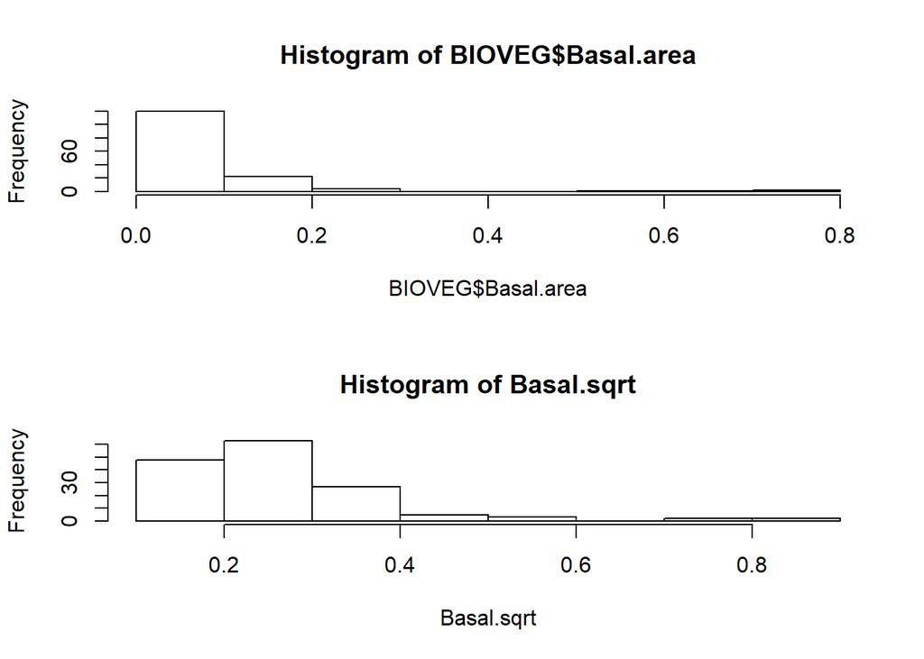

```r
Basal.sqrt <- sqrt(BIOVEG$Basal.area)
par(mfrow=c(2,1)) # let's check the transformation using histograms
hist(BIOVEG$Basal.area)
hist(Basal.sqrt)
```

#### Inverse:

```r
Basal.inv <- 1 / BIOVEG$Basal.area
head(Basal.inv, 10) # reading only the first 10 rows
```

```
##  [1] 17.241379  8.333333 11.111111  7.812500 10.869565 50.000000  6.993007
##  [8]  7.194245  1.386963  9.345794
```

#### Arcsine square root:

Can be used for data that range between zero and 1. Often indicated for binomial data (proportions/ percentages), but it is preferable to use a model with binomial distribution rather than an arcsine square root transformation in this case.

```r
Hogweed <- read.table("Hogweed.csv", header=T, sep=",", dec=".")
head(Hogweed, 4) # reading only the first 4 rows of data
```

```
##   Plot Study.area  Habitat.type Year Veg.height Veg.cover Species.richness
## 1   s1        VOL ruderal.grass 2002        0.5        70               18
## 2   s2        VOL ruderal.grass 2002        0.7        65               19
## 3   s3        VOL ruderal.grass 2002        0.4        30               16
## 4   s4        VOL ruderal.grass 2002        0.9        90               23
##   Hogweed.height Hogweed.cover Land.use Disturbance Altitude Inclination
## 1            0.9            80     NONE   TREESHRUB  295.653           2
## 2            1.4            65     NONE   TREESHRUB  295.653           2
## 3            1.7            90     NONE   TREESHRUB  295.653           2
## 4            1.0            20     NONE        NONE  292.112           2
##   Exposition N_perc P_mg_100g K_mg_100g
## 1          W   0.19      3.99     22.27
## 2          W   0.19      3.56     12.49
## 3          W   0.19      8.44     39.95
## 4          W   0.12      2.53     12.34
```

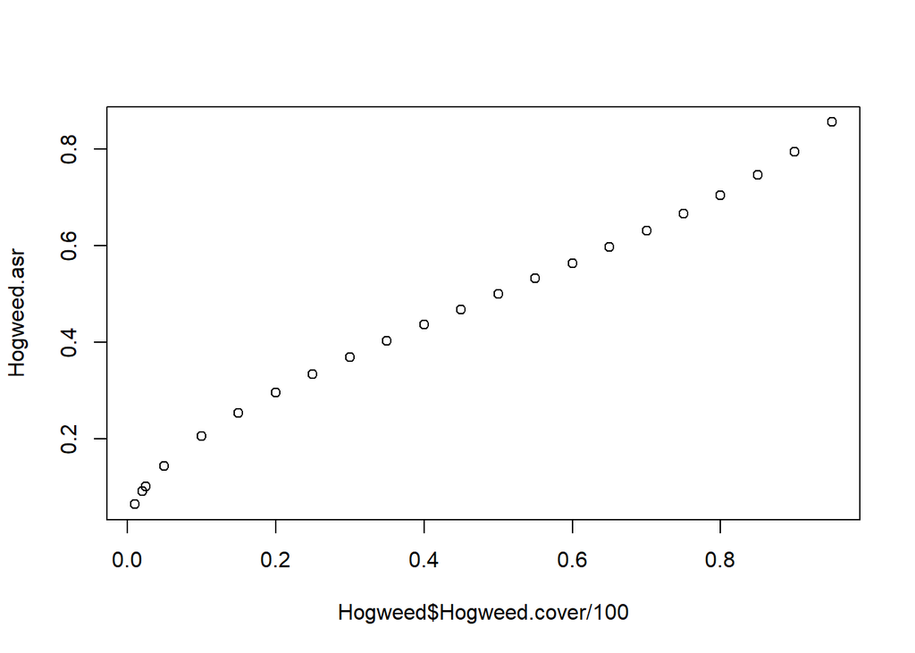

```r
Hogweed.asr <- asin(sqrt(Hogweed$Hogweed.cover/100))*2/pi
plot(Hogweed$Hogweed.cover/100, Hogweed.asr)
```

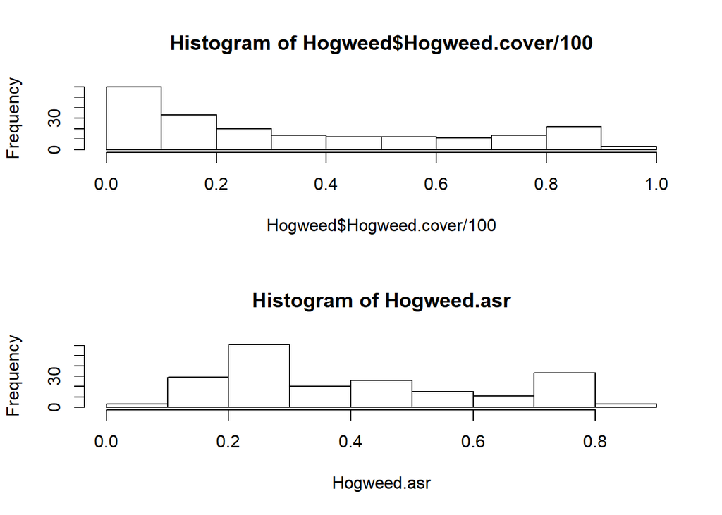

```r
par(mfrow=c(2,1))
hist(Hogweed$Hogweed.cover/100)
hist(Hogweed.asr)
```

### ONE SAMPLE TEST

Indication: to test one sample mean against zero to verify whether there is a significant difference.

#### Parametric

#### T-TEST - One sample

```r
BIOVEG <- read.table("BIOVEG3.csv", header=T, sep=",", dec=".")
head(BIOVEG, 4) # reading only the first 4 rows
```

```
##           type Plot  Site                Species Richness Diameter
## 1 Semidecidual p001 AREA1 Alchornea_triplinervia        8    27.12
## 2 Semidecidual p002 AREA1     Amaioua_intermedia       10    39.15
## 3 Semidecidual p003 AREA1          Aniba_firmula       10    33.93
## 4 Semidecidual p004 AREA1          Annona_cacans       10    40.43
##   Mean_diameter Basal.area Abundance Precipitation_mean Temperature_mean
## 1         6.357      0.058         7               1250             24.4
## 2         6.524      0.120        12               1250             24.4
## 3         6.632      0.090        10               1250             24.4
## 4         6.626      0.128        19               1250             24.4
##   Mortality Recruitment local.x local.y  utm.x   utm.y local.utm.x
## 1      6.94       14.34       0       0 747923 7807727      747923
## 2      2.74        6.94     -10       0 747923 7807727      747913
## 3      1.71        2.35     -20       0 747923 7807727      747903
## 4      1.60        2.47     -30       0 747923 7807727      747893
##   local.utm.y
## 1     7807727
## 2     7807727
## 3     7807727
## 4     7807727
```

```r
# Usage:

t.test(BIOVEG$Basal.area, mu=0) # test against zero
```

```
##
##  One Sample t-test
##
## data:  BIOVEG$Basal.area
## t = 9.3933, df = 149, p-value < 2.2e-16
## alternative hypothesis: true mean is not equal to 0
## 95 percent confidence interval:
##  0.06618719 0.10145281
## sample estimates:
## mean of x
##   0.08382
```

#### Nonparametric

#### Wilcoxon Signed Rank Test

```r
BIOVEG <- read.table("BIOVEG3.csv", header=T, sep=",", dec=".")
head(BIOVEG, 4) # reading only the first 4 rows
```

```
##           type Plot  Site                Species Richness Diameter
## 1 Semidecidual p001 AREA1 Alchornea_triplinervia        8    27.12
## 2 Semidecidual p002 AREA1     Amaioua_intermedia       10    39.15
## 3 Semidecidual p003 AREA1          Aniba_firmula       10    33.93
## 4 Semidecidual p004 AREA1          Annona_cacans       10    40.43
##   Mean_diameter Basal.area Abundance Precipitation_mean Temperature_mean
## 1         6.357      0.058         7               1250             24.4
## 2         6.524      0.120        12               1250             24.4
## 3         6.632      0.090        10               1250             24.4
## 4         6.626      0.128        19               1250             24.4
##   Mortality Recruitment local.x local.y  utm.x   utm.y local.utm.x
## 1      6.94       14.34       0       0 747923 7807727      747923
## 2      2.74        6.94     -10       0 747923 7807727      747913
## 3      1.71        2.35     -20       0 747923 7807727      747903
## 4      1.60        2.47     -30       0 747923 7807727      747893
##   local.utm.y
## 1     7807727
## 2     7807727
## 3     7807727
## 4     7807727
```

```r
# Usage:

wilcox.test(BIOVEG$Basal.area, mu=0)
```

```
##
##  Wilcoxon signed rank test with continuity correction
##
## data:  BIOVEG$Basal.area
## V = 11325, p-value < 2.2e-16
## alternative hypothesis: true location is not equal to 0
```

### TWO SAMPLE TEST

Indication: to compare two independent samples.

#### Independent Two samples

#### Parametric: T-TEST - Two sample:

```r
BIOVEG <- read.table("BIOVEG3.csv", header=T, sep=",", dec=".")
head(BIOVEG, 4) # reading only the first 4 rows
```

```
##           type Plot  Site                Species Richness Diameter
## 1 Semidecidual p001 AREA1 Alchornea_triplinervia        8    27.12
## 2 Semidecidual p002 AREA1     Amaioua_intermedia       10    39.15
## 3 Semidecidual p003 AREA1          Aniba_firmula       10    33.93
## 4 Semidecidual p004 AREA1          Annona_cacans       10    40.43
##   Mean_diameter Basal.area Abundance Precipitation_mean Temperature_mean
## 1         6.357      0.058         7               1250             24.4
## 2         6.524      0.120        12               1250             24.4
## 3         6.632      0.090        10               1250             24.4
## 4         6.626      0.128        19               1250             24.4
##   Mortality Recruitment local.x local.y  utm.x   utm.y local.utm.x
## 1      6.94       14.34       0       0 747923 7807727      747923
## 2      2.74        6.94     -10       0 747923 7807727      747913
## 3      1.71        2.35     -20       0 747923 7807727      747903
## 4      1.60        2.47     -30       0 747923 7807727      747893
##   local.utm.y
## 1     7807727
## 2     7807727
## 3     7807727
## 4     7807727
```

```r
# Testing whether vegetation type differ in tree basal area average

# usage:

t.test(BIOVEG$Basal.area[BIOVEG$type=="Aluvial"],
       BIOVEG$Basal.area[BIOVEG$type=="Ombrofila"],alternative="two.sided")
```

```
##
##  Welch Two Sample t-test
##
## data:  BIOVEG$Basal.area[BIOVEG$type == "Aluvial"] and BIOVEG$Basal.area[BIOVEG$type == "Ombrofila"]
## t = -0.9419, df = 61.174, p-value = 0.3499
## alternative hypothesis: true difference in means is not equal to 0
## 95 percent confidence interval:
##  -0.04934092  0.01774092
## sample estimates:
## mean of x mean of y
##    0.0599    0.0757
```

```r
# Testing whether a vegetation type has significantly less tree basal
# than the other

t.test(BIOVEG$Basal.area[BIOVEG$type=="Aluvial"],
       BIOVEG$Basal.area[BIOVEG$type=="Ombrofila"], alternative="less",
       var.equal=TRUE)
```

```
##
##  Two Sample t-test
##
## data:  BIOVEG$Basal.area[BIOVEG$type == "Aluvial"] and BIOVEG$Basal.area[BIOVEG$type == "Ombrofila"]
## t = -0.9419, df = 98, p-value = 0.1743
## alternative hypothesis: true difference in means is less than 0
## 95 percent confidence interval:
##        -Inf 0.01205505
## sample estimates:
## mean of x mean of y
##    0.0599    0.0757
```

#### Dependent samples

Indication: to compare two dependent samples.

#### Parametric: PAIRED T-TEST

```r
t.test(BIOVEG$Basal.area[BIOVEG$type=="Aluvial"],
       BIOVEG$Basal.area[BIOVEG$type=="Ombrofila"],paired = TRUE)
```

```
##
##  Paired t-test
##
## data:  BIOVEG$Basal.area[BIOVEG$type == "Aluvial"] and BIOVEG$Basal.area[BIOVEG$type == "Ombrofila"]
## t = -0.92713, df = 49, p-value = 0.3584
## alternative hypothesis: true difference in means is not equal to 0
## 95 percent confidence interval:
##  -0.05004692  0.01844692
## sample estimates:
## mean of the differences
##                 -0.0158
```

#### Independent Two samples

#### Nonparametric: Wilcoxon Rank-Sum Test (or Mann-Whitney U-test)

```r
BIOVEG <- read.table("BIOVEG3.csv", header=T, sep=",", dec=".")
head(BIOVEG, 4)
```

```
##           type Plot  Site                Species Richness Diameter
## 1 Semidecidual p001 AREA1 Alchornea_triplinervia        8    27.12
## 2 Semidecidual p002 AREA1     Amaioua_intermedia       10    39.15
## 3 Semidecidual p003 AREA1          Aniba_firmula       10    33.93
## 4 Semidecidual p004 AREA1          Annona_cacans       10    40.43
##   Mean_diameter Basal.area Abundance Precipitation_mean Temperature_mean
## 1         6.357      0.058         7               1250             24.4
## 2         6.524      0.120        12               1250             24.4
## 3         6.632      0.090        10               1250             24.4
## 4         6.626      0.128        19               1250             24.4
##   Mortality Recruitment local.x local.y  utm.x   utm.y local.utm.x
## 1      6.94       14.34       0       0 747923 7807727      747923
## 2      2.74        6.94     -10       0 747923 7807727      747913
## 3      1.71        2.35     -20       0 747923 7807727      747903
## 4      1.60        2.47     -30       0 747923 7807727      747893
##   local.utm.y
## 1     7807727
## 2     7807727
## 3     7807727
## 4     7807727
```

Where y is numeric and A is a binary factor (presence or absence, 0 or 1, or similar) we can use the formula notation in wilcox.test

```r
BIOVEG$Aluvial <- ifelse(BIOVEG$type=="Aluvial", 1, 0) # create binary factor
wilcox.test(BIOVEG$Basal.area ~ BIOVEG$Aluvial)
```

```
##
##  Wilcoxon rank sum test with continuity correction
##
## data:  BIOVEG$Basal.area by BIOVEG$Aluvial
## W = 2754, p-value = 0.3121
## alternative hypothesis: true location shift is not equal to 0
```

independent 2-group Mann-Whitney U Test; here we specify the two groups to be compared using indexing (square brackets)

```r
wilcox.test(BIOVEG$Basal.area[BIOVEG$type=="Aluvial"],
            BIOVEG$Basal.area[BIOVEG$type=="Ombrofila"], paired=FALSE)
```

```
##
##  Wilcoxon rank sum test with continuity correction
##
## data:  BIOVEG$Basal.area[BIOVEG$type == "Aluvial"] and BIOVEG$Basal.area[BIOVEG$type == "Ombrofila"]
## W = 1385.5, p-value = 0.3519
## alternative hypothesis: true location shift is not equal to 0
```

#### Dependent (i.e. Paired) Two-Sample

Indication: the same function as the Wilcoxon test and two sample T-test, but addressing paired samples. This applies to data which has been collected on the same plots, for example, either on the same date or at different dates (e.g. comparison between basal area in 2010 and 2014. The basal area of 2014 in general is dependent on how much was accumulated in 2010).

Another test dataset describes the soil nutrient content of a number of different plots. The quantities of each nutrient (N, P, K) were derived from a single soil sample per plot.

```r
Hogweed <- read.table("Hogweed.csv", header=T, sep=",", dec=".")
head(Hogweed, 4)
```

```
##   Plot Study.area  Habitat.type Year Veg.height Veg.cover Species.richness
## 1   s1        VOL ruderal.grass 2002        0.5        70               18
## 2   s2        VOL ruderal.grass 2002        0.7        65               19
## 3   s3        VOL ruderal.grass 2002        0.4        30               16
## 4   s4        VOL ruderal.grass 2002        0.9        90               23
##   Hogweed.height Hogweed.cover Land.use Disturbance Altitude Inclination
## 1            0.9            80     NONE   TREESHRUB  295.653           2
## 2            1.4            65     NONE   TREESHRUB  295.653           2
## 3            1.7            90     NONE   TREESHRUB  295.653           2
## 4            1.0            20     NONE        NONE  292.112           2
##   Exposition N_perc P_mg_100g K_mg_100g
## 1          W   0.19      3.99     22.27
## 2          W   0.19      3.56     12.49
## 3          W   0.19      8.44     39.95
## 4          W   0.12      2.53     12.34
```

When you have dependent samples, in “paired” insert TRUE. For independent samples insert FALSE.

```r
# Usage:

wilcox.test(Hogweed$P_mg_100g, Hogweed$K_mg_100g, paired=TRUE)
```

```
##
##  Wilcoxon signed rank test with continuity correction
##
## data:  Hogweed$P_mg_100g and Hogweed$K_mg_100g
## V = 891, p-value < 2.2e-16
## alternative hypothesis: true location shift is not equal to 0
```

### ANALYSIS OF VARIANCE

Indication: tests for differences between the means of more than two groups e.g. Diameter in treatment1, Diameter in treatment2, Diameter in treatment3).

Note: All Analyses below relate to variance, one-sample and two-sample. The majority of this analysis can be completed using the basic pre-loaded built-in “stats” package. To perform Dunn’s test (Post hoc), which follows Kruskal-Wallis,the “dunn.test” package must be installed.

#### Parametric tests: One-Way Anova

Note 2: transformations of the dependent variable, e.g. log, can be specified in the syntax of ANOVA and other functions directly.

```r
# usage:

BIOVEG <- read.table("BIOVEG3.csv", header=T, sep=",", dec=".")
head(BIOVEG, 4)
```

```
##           type Plot  Site                Species Richness Diameter
## 1 Semidecidual p001 AREA1 Alchornea_triplinervia        8    27.12
## 2 Semidecidual p002 AREA1     Amaioua_intermedia       10    39.15
## 3 Semidecidual p003 AREA1          Aniba_firmula       10    33.93
## 4 Semidecidual p004 AREA1          Annona_cacans       10    40.43
##   Mean_diameter Basal.area Abundance Precipitation_mean Temperature_mean
## 1         6.357      0.058         7               1250             24.4
## 2         6.524      0.120        12               1250             24.4
## 3         6.632      0.090        10               1250             24.4
## 4         6.626      0.128        19               1250             24.4
##   Mortality Recruitment local.x local.y  utm.x   utm.y local.utm.x
## 1      6.94       14.34       0       0 747923 7807727      747923
## 2      2.74        6.94     -10       0 747923 7807727      747913
## 3      1.71        2.35     -20       0 747923 7807727      747903
## 4      1.60        2.47     -30       0 747923 7807727      747893
##   local.utm.y
## 1     7807727
## 2     7807727
## 3     7807727
## 4     7807727
```

```r
aov(log(Diameter) ~ type, data=BIOVEG)
```

```
## Call:
##    aov(formula = log(Diameter) ~ type, data = BIOVEG)
##
## Terms:
##                      type Residuals
## Sum of Squares   1.590824 22.039904
## Deg. of Freedom         2       147
##
## Residual standard error: 0.3872097
## Estimated effects may be unbalanced
```

```r
results <- aov(log(Diameter) ~ type, data=BIOVEG)
summary(results)
```

```
##              Df Sum Sq Mean Sq F value  Pr(>F)
## type          2  1.591  0.7954   5.305 0.00596 **
## Residuals   147 22.040  0.1499
## ---
## Signif. codes:  0 '***' 0.001 '**' 0.01 '*' 0.05 '.' 0.1 ' ' 1
```

#### Tukey test (post hoc)

Indication: to identify when there is a significant difference between categories previously shown as overall result by parametric ANOVA.

```r
# Usage:

a1 <- aov(log(BIOVEG$Diameter) ~ BIOVEG$type)
posthoc <- TukeyHSD(x=a1, 'BIOVEG$type', conf.level=0.95)
print(posthoc)
```

```
##   Tukey multiple comparisons of means
##     95% family-wise confidence level
##
## Fit: aov(formula = log(BIOVEG$Diameter) ~ BIOVEG$type)
##
## $`BIOVEG$type`
##                              diff         lwr       upr     p adj
## Ombrofila-Aluvial      -0.0280405 -0.21139925 0.1553182 0.9303204
## Semidecidual-Aluvial    0.2030858  0.01972702 0.3864445 0.0259703
## Semidecidual-Ombrofila  0.2311263  0.04776753 0.4144850 0.0092752
```

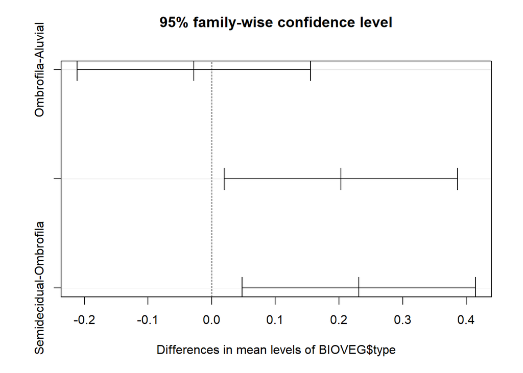

```r
plot(posthoc)
```

#### Non-Parametric tests: Kruskal-Wallis

Indication: use following a significant result in the Kruskal-Wallace test (a non-parametric analysis, the underlying distribution is not assumed in advance).

```r
BIOVEG <- read.table("BIOVEG3.csv", header=T, sep=",", dec=".")
head(BIOVEG, 4)
```

```
##           type Plot  Site                Species Richness Diameter
## 1 Semidecidual p001 AREA1 Alchornea_triplinervia        8    27.12
## 2 Semidecidual p002 AREA1     Amaioua_intermedia       10    39.15
## 3 Semidecidual p003 AREA1          Aniba_firmula       10    33.93
## 4 Semidecidual p004 AREA1          Annona_cacans       10    40.43
##   Mean_diameter Basal.area Abundance Precipitation_mean Temperature_mean
## 1         6.357      0.058         7               1250             24.4
## 2         6.524      0.120        12               1250             24.4
## 3         6.632      0.090        10               1250             24.4
## 4         6.626      0.128        19               1250             24.4
##   Mortality Recruitment local.x local.y  utm.x   utm.y local.utm.x
## 1      6.94       14.34       0       0 747923 7807727      747923
## 2      2.74        6.94     -10       0 747923 7807727      747913
## 3      1.71        2.35     -20       0 747923 7807727      747903
## 4      1.60        2.47     -30       0 747923 7807727      747893
##   local.utm.y
## 1     7807727
## 2     7807727
## 3     7807727
## 4     7807727
```

```r
#Usage:

r4<- kruskal.test(BIOVEG$Basal.area ~ BIOVEG$type)
r4
```

```
##
##  Kruskal-Wallis rank sum test
##
## data:  BIOVEG$Basal.area by BIOVEG$type
## Kruskal-Wallis chi-squared = 10.899, df = 2, p-value = 0.004299
```

#### Dunn’s Test (post hoc)

It performs the same function as a TukeyHSD test following ANOVA, but here is following Kruskal-Wallis.

install.packages(“dunn.test”)

```r
# Usage:

library(dunn.test)

dunn.test(BIOVEG$Basal.area, g=BIOVEG$type, kw=TRUE, label=TRUE, wrap=TRUE,
          table=TRUE, list=FALSE, rmc=FALSE, alpha=0.05)
```

```
##   Kruskal-Wallis rank sum test
##
## data: x and group
## Kruskal-Wallis chi-squared = 10.8989, df = 2, p-value = 0
##
##
##                            Comparison of x by group
##                                 (No adjustment)
## Col Mean-|
## Row Mean |    Aluvial   Ombrofil
## ---------+----------------------
## Ombrofil |   0.694041
##          |     0.2438
## Semideci |  -2.448136  -3.142178
##          |    0.0072*    0.0008*
##
## alpha = 0.05
## Reject Ho if p <= alpha/2
```

```r
# when the command line extends beyond more than one row in the text, be sure  to select all rows to run the complete command.
```

### Independence test - Chi-squared

The Chi-squared test is one of the most commonly used tests in biology and biomedicine because it can test if one variable is dependent or not on a certain category. In the example below we use the phenology stages of a species and the abundance of individuals counted at each stage over 4 months (Feb, Mar, Apr, May). Our aim is to check if the abundances at each stage are dependent on the months. In case Chi-squared is significant and, thus, shows dependence, you need to split the table into two in a 2 x 2 format and run the test again. This post-hoc test is called: Partition of Chi-squared. Further Information about this test is widely available online.

install and load the MASS package:

```r
# install.packages("MASS")
library(MASS)
```

To build a contingency from columns of a data table you can use. For example:

```r
# tbl <- table(Data$flowering, Data$fruits, Data$Month)
```

Here, we will just create a contingency table “manually”:

```r
tbl <- rbind(c(7,1,3,9), c(8,5,2,0))
colnames(tbl) <- c("Feb", "Mar", "Apr", "May")
rownames(tbl) <- c("Flowering", "Fruits")
tbl
```

```
##           Feb Mar Apr May
## Flowering   7   1   3   9
## Fruits      8   5   2   0
```

```r
# Usage:

chisq.test(tbl) # normal p-value of Chi-squared test
```

```
##
##  Pearson's Chi-squared test
##
## data:  tbl
## X-squared = 11.453, df = 3, p-value = 0.009513
```

```r
chisq.test(tbl, simulate.p.value=TRUE) # simulated p-value (Monte Carlo test)
```

```
##
##  Pearson's Chi-squared test with simulated p-value (based on 2000
##  replicates)
##
## data:  tbl
## X-squared = 11.453, df = NA, p-value = 0.007996
```

```r
# "Posthoc" test comparing only two month

tbl.1 <- tbl[,c("Mar", "Apr")]
tbl.1
```

```
##           Mar Apr
## Flowering   1   3
## Fruits      5   2
```

```r
chisq.test(tbl.1)
```

```
##
##  Pearson's Chi-squared test with Yates' continuity correction
##
## data:  tbl.1
## X-squared = 0.73661, df = 1, p-value = 0.3907
```

### CORRELATION ANALYSIS

#### Pearson’s correlation test

use PerformanceAnalytics package

```r
BIOVEG <- read.table("BIOVEG3.csv", header=T, sep=",", dec=".")
head(BIOVEG, 4)
```

```
##           type Plot  Site                Species Richness Diameter
## 1 Semidecidual p001 AREA1 Alchornea_triplinervia        8    27.12
## 2 Semidecidual p002 AREA1     Amaioua_intermedia       10    39.15
## 3 Semidecidual p003 AREA1          Aniba_firmula       10    33.93
## 4 Semidecidual p004 AREA1          Annona_cacans       10    40.43
##   Mean_diameter Basal.area Abundance Precipitation_mean Temperature_mean
## 1         6.357      0.058         7               1250             24.4
## 2         6.524      0.120        12               1250             24.4
## 3         6.632      0.090        10               1250             24.4
## 4         6.626      0.128        19               1250             24.4
##   Mortality Recruitment local.x local.y  utm.x   utm.y local.utm.x
## 1      6.94       14.34       0       0 747923 7807727      747923
## 2      2.74        6.94     -10       0 747923 7807727      747913
## 3      1.71        2.35     -20       0 747923 7807727      747903
## 4      1.60        2.47     -30       0 747923 7807727      747893
##   local.utm.y
## 1     7807727
## 2     7807727
## 3     7807727
## 4     7807727
```

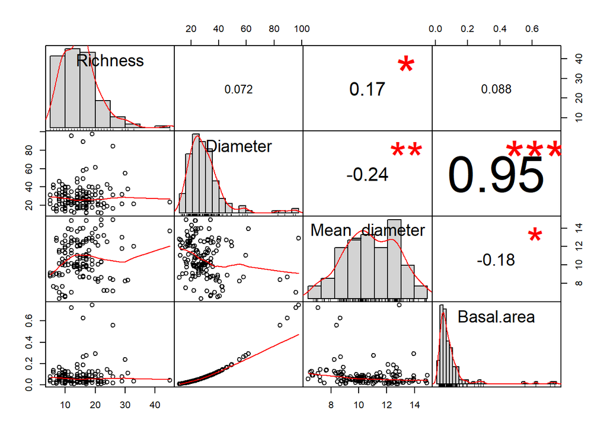

```r
# Usage:

# install.packages("PerformanceAnalytics")
library(PerformanceAnalytics)
chart.Correlation(BIOVEG[,c(5, 6, 7, 8)])
```

```r
correlacao<- cor(BIOVEG[,c(5, 6, 7, 8)])
round(correlacao, digits=2)
```

```
##               Richness Diameter Mean_diameter Basal.area
## Richness          1.00     0.07          0.17       0.09
## Diameter          0.07     1.00         -0.24       0.95
## Mean_diameter     0.17    -0.24          1.00      -0.18
## Basal.area        0.09     0.95         -0.18       1.00
```

Correlation test between just two variables:

```r
## use the default R function "cor.test"

cor.test(BIOVEG$Richness, BIOVEG$Basal.area)
```

```
##
##  Pearson's product-moment correlation
##
## data:  BIOVEG$Richness and BIOVEG$Basal.area
## t = 1.0703, df = 148, p-value = 0.2862
## alternative hypothesis: true correlation is not equal to 0
## 95 percent confidence interval:
##  -0.07365322  0.24447057
## sample estimates:
##        cor
## 0.08764283
```

The number between parentheses are the column numbers of your data file (e.g. Excel file). This is how you select the variables whose correlation you want to check.

REMEMBER: correlation just shows you if one data value increases/ decreases with the other, but it does not say that they are dependent on each other. To check dependence between variables you need to test their relation and for that there are regression models. However, even regression models do not prove that there is a causal relationships between the variables. Correlation and regression cannot discern between real causal effects and spurious correlations (that are caused by a third variable/ other variables).

#### Spearman’s correlation test

There is a perpetual discussion among statisticians about whetherPearson analysis assumes strictly normality, but a large majority of high impact literature continues to use it, even in non-normal cases. Some researchers recommend Spearman, but, for a number of reasons, its application is more limited than Pearson. Please read about this subject further if it applies to your analysis.

If you want to use Spearman rank correlation just use the ‘method’ argument:

[figure not shown]

```r
chart.Correlation(BIOVEG[,c(5, 6, 7, 8)], method="spearman")
```

```r
correlacao<- cor(BIOVEG[,c(5, 6, 7, 8)], method="spearman")
round(correlacao, digits=2)
```

```
##               Richness Diameter Mean_diameter Basal.area
## Richness          1.00     0.00          0.16       0.00
## Diameter          0.00     1.00         -0.29       1.00
## Mean_diameter     0.16    -0.29          1.00      -0.29
## Basal.area        0.00     1.00         -0.29       1.00
```

Correlation test between just two variables:

```r
## use the default R function "cor.test"

cor.test(BIOVEG$Richness, BIOVEG$Basal.area, method="spearman")
```

```
##
##  Spearman's rank correlation rho
##
## data:  BIOVEG$Richness and BIOVEG$Basal.area
## S = 563580, p-value = 0.981
## alternative hypothesis: true rho is not equal to 0
## sample estimates:
##         rho
## -0.00196546
```

Sometimes Spearman ranking is not able to precisely compute p-values. Thus, an option is also test Pearson and provide the results of both.

#### VIF - Variance Inflation Factor

Among the most robust approaches used nowadays, the variance inflation factor (VIF) is the quotient of the variance in a model with multiple terms (predictors) by the variance of a model with one term alone. This is a great method to quantify the severity of multicollinearity in an ordinary least squares regression analysis (e.g. LM, LME, GLS, etc). VIF provides an index that returns an outcome measuring how much the variance (the square of the estimate’s standard deviation) of an estimated model coefficient is increased because of collinearity.

For further details and information on the statistical backbone and potential of VIF, please read the great revision and simulations of Dormann et al. 2013 and Zurr et al.2010.

Dormann et al. Collinearity: A review of methods to deal with it and a simulation study evaluating their performance. Ecography, 36(1): 27-46, 2013.

Zuur AF, Ieno EN & Elphick CS. A protocol for data exploration to avoid common statistical problems. Methods in Ecology and Evolution 1: 3-14, 2010.

We use the function vif of the package car to calculate the variance inflation factor:

```r
# install.packages("car")
library(car)


BIODIV.vif<- lm(Species.richness ~ P_mg_100g + Hogweed.cover + N_perc +
                  Habitat.type, data=Hogweed)

vif(BIODIV.vif)
```

```
##                   GVIF Df GVIF^(1/(2*Df))
## P_mg_100g     1.093411  1        1.045663
## Hogweed.cover 1.293545  1        1.137341
## N_perc        1.122377  1        1.059423
## Habitat.type  1.434640  4        1.046147
```

The outcome shows that all predictors have VIF < 5, thus they can be kept together in the same model.

### Diagnostic for linearity

To check for linear relationships among dependent (Y) and predictor variables (X) we can use the function “crPlots” of the package “car”. This function returns a graph that bases the diagnostic on the residuals of the model. The more closely the two lines (solid and dashed) fit each other, the more linear is the relationship among Y and X.

```r
library(car) # graphical diagnostic for linearity

Hogweed <- read.table("Hogweed.csv", header=T, sep=",", dec=".")
head(Hogweed,4)
```

```
##   Plot Study.area  Habitat.type Year Veg.height Veg.cover Species.richness
## 1   s1        VOL ruderal.grass 2002        0.5        70               18
## 2   s2        VOL ruderal.grass 2002        0.7        65               19
## 3   s3        VOL ruderal.grass 2002        0.4        30               16
## 4   s4        VOL ruderal.grass 2002        0.9        90               23
##   Hogweed.height Hogweed.cover Land.use Disturbance Altitude Inclination
## 1            0.9            80     NONE   TREESHRUB  295.653           2
## 2            1.4            65     NONE   TREESHRUB  295.653           2
## 3            1.7            90     NONE   TREESHRUB  295.653           2
## 4            1.0            20     NONE        NONE  292.112           2
##   Exposition N_perc P_mg_100g K_mg_100g
## 1          W   0.19      3.99     22.27
## 2          W   0.19      3.56     12.49
## 3          W   0.19      8.44     39.95
## 4          W   0.12      2.53     12.34
```

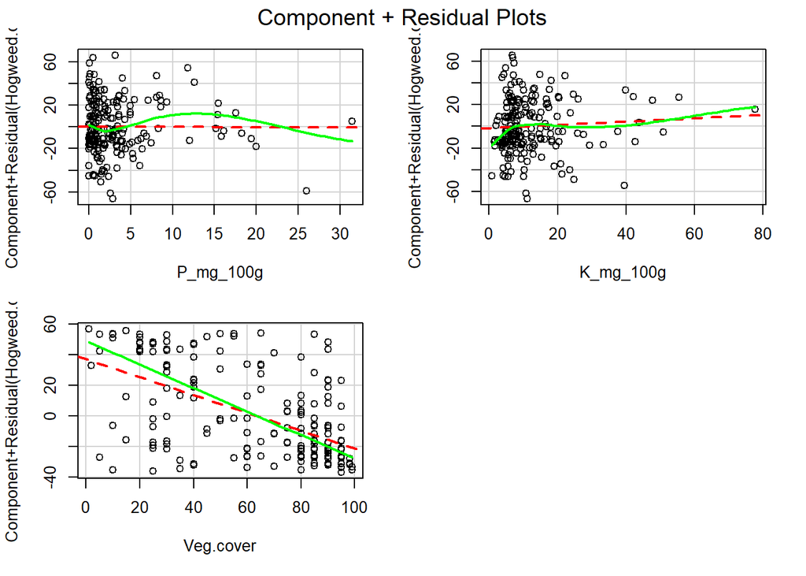

```r
DBH<- glm(Hogweed.cover ~ P_mg_100g + K_mg_100g + Veg.cover, data=Hogweed,
                                                       family="gaussian")

crPlots(DBH, col.lines=c("red", "green"))
```

In the diagnostic we can see that the predictor “Veg.cover” shows the best, and an acceptable, fit for linearity. This is indicated by the close fit between the red line (best fit) and green line. Conversely, the linearity of “P_mg_100g” and “K_mg_100g” deviates considerably.

### REGRESSION

Indication: Regression analysis is a statistical approach for estimating the relationships between a dependent variable (axis Y and commonly called the outcome variable’) and one or more independent variables (predictors).There are linear and nonlinear regression models, although the linear ones are the most common form of used regression analysis.

#### LM (Linear Model)

This is the most famous type of regression of analysis and relies in the assumptions of the Ordinary least squares: normal distribution, homoscedasticity, linearity between, predictors and dependent variable, weak multicollinearity among predictors, independence of errors and residuals not correlated.

```r
Hogweed <- read.table("Hogweed.csv", header=T, sep=",", dec=".")
head(Hogweed,4)
```

```
##   Plot Study.area  Habitat.type Year Veg.height Veg.cover Species.richness
## 1   s1        VOL ruderal.grass 2002        0.5        70               18
## 2   s2        VOL ruderal.grass 2002        0.7        65               19
## 3   s3        VOL ruderal.grass 2002        0.4        30               16
## 4   s4        VOL ruderal.grass 2002        0.9        90               23
##   Hogweed.height Hogweed.cover Land.use Disturbance Altitude Inclination
## 1            0.9            80     NONE   TREESHRUB  295.653           2
## 2            1.4            65     NONE   TREESHRUB  295.653           2
## 3            1.7            90     NONE   TREESHRUB  295.653           2
## 4            1.0            20     NONE        NONE  292.112           2
##   Exposition N_perc P_mg_100g K_mg_100g
## 1          W   0.19      3.99     22.27
## 2          W   0.19      3.56     12.49
## 3          W   0.19      8.44     39.95
## 4          W   0.12      2.53     12.34
```

```r
# install.packages("car")
library(car) # Anova function
```

```r
# Usage:
# Model:

BIODIV.pre<- lm(Species.richness ~ P_mg_100g + Habitat.type, data=Hogweed)

summary(BIODIV.pre)
```

```
##
## Call:
## lm(formula = Species.richness ~ P_mg_100g + Habitat.type, data = Hogweed)
##
## Residuals:
##     Min      1Q  Median      3Q     Max
## -16.117  -5.058  -1.152   4.912  25.871
##
## Coefficients:
##                           Estimate Std. Error t value Pr(>|t|)
## (Intercept)                25.1319     1.2887  19.503  < 2e-16 ***
## P_mg_100g                  -0.2768     0.1170  -2.366 0.018946 *
## Habitat.typeruderal.grass  -2.2314     1.6361  -1.364 0.174184
## Habitat.typetall.herbs     -9.4813     1.5449  -6.137  4.6e-09 ***
## Habitat.typewasteland      -2.2797     2.2731  -1.003 0.317153
## Habitat.typewoodland       -7.8197     2.1460  -3.644 0.000344 ***
## ---
## Signif. codes:  0 '***' 0.001 '**' 0.01 '*' 0.05 '.' 0.1 ' ' 1
##
## Residual standard error: 7.564 on 195 degrees of freedom
## Multiple R-squared:  0.2505, Adjusted R-squared:  0.2313
## F-statistic: 13.04 on 5 and 195 DF,  p-value: 5.965e-11
```

```r
# Anova of the model using the package car:
Anova(BIODIV.pre)
```

```
## Anova Table (Type II tests)
##
## Response: Species.richness
##               Sum Sq  Df F value    Pr(>F)
## P_mg_100g      320.4   1  5.5995   0.01895 *
## Habitat.type  3060.2   4 13.3714 1.199e-09 ***
## Residuals    11156.9 195
## ---
## Signif. codes:  0 '***' 0.001 '**' 0.01 '*' 0.05 '.' 0.1 ' ' 1
```

```r
# Anova of the model using the built-in R function:
BIODIV.lm.aov <- anova(BIODIV.pre, test="F")
BIODIV.lm.aov
```

```
## Analysis of Variance Table
##
## Response: Species.richness
##               Df  Sum Sq Mean Sq F value    Pr(>F)
## P_mg_100g      1   668.9  668.94  11.692 0.0007644 ***
## Habitat.type   4  3060.2  765.04  13.371 1.199e-09 ***
## Residuals    195 11156.9   57.21
## ---
## Signif. codes:  0 '***' 0.001 '**' 0.01 '*' 0.05 '.' 0.1 ' ' 1
```

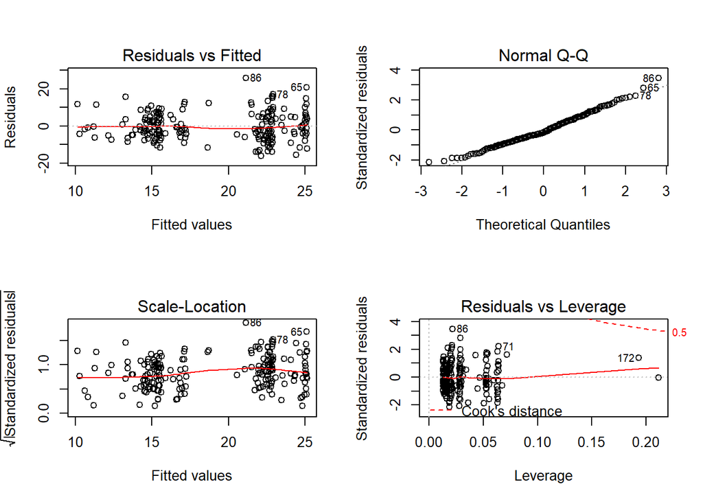

```r
# Residuals
x11(width=12, height=12)
par(mfrow=c(2,2))
plot(BIODIV.pre)
```

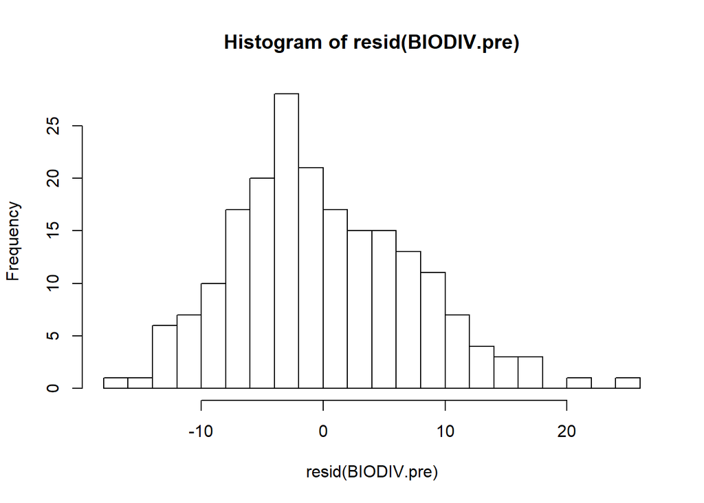

```r
hist(resid(BIODIV.pre),breaks=20)
```

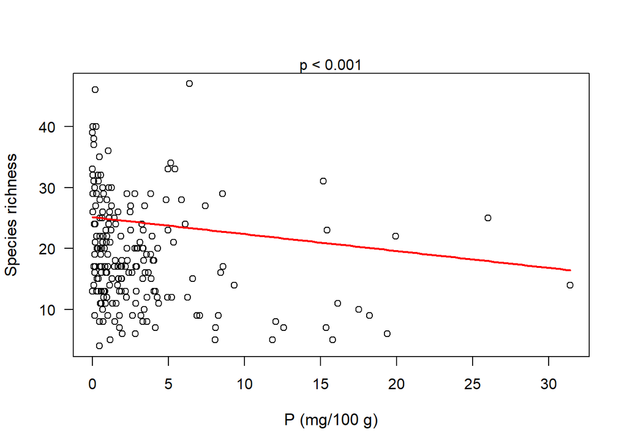

```r
# Scatterplot graph:

b.0.BIODIV<- BIODIV.pre$coefficients[1]
b.1.BIODIV<- BIODIV.pre$coefficients[2]
plot(Hogweed$Species.richness ~ Hogweed$P_mg_100g, las=1,
     ylab="Species richness", xlab="P (mg/100 g)", cex.lab=1.1)
curve(b.0.BIODIV + b.1.BIODIV*x, add=TRUE, col="red", lwd=2)
mtext(ifelse(BIODIV.lm.aov[1,5]<0.001, "p < 0.001",
      paste("p = ", round(BIODIV.lm.aov[1,5],3))))
```

To construct the curve (or line) in this LM example, the dependent variable, Species richness, is on the y axis and the metric predictor variable, phosphorous, is on the x axis. The regression line is calculated using the intercept (b.0.BIODIV) plus the estimate of phosphorous (b.1.BIODIV) multiplied by x. The insertion of the P-value of ANOVA is placed according to the location of values in the ANOVA output. That is, the “P_mg_100g” is being tested in relation to “Species.richness” and it’s located in the first row of the ANOVA output and its P-value on the 5th column in this row. Thus: BIODIV.lm.aov[1,5]. If you have done any data transformation before (log, square …) you must include it in the syntax of the scatterplot, e.g. log(Hogweed$Species.richness). If the variable include zeros, add a constant, e.g. +1, before taking the log.

#### GLM (Generalized Linear Models)

Note: in GLM you must specify the distribution family of the dependent variable. Thus:

- Gaussian (normal) distribution: Continuous data (e.g. body weight, basal area, height). If the residuals don’t satisfactorily fit the Gaussian distribution, you can try Gamma distribution. BUT, first of all read about both kinds of distribution before you decide which to use . Gamma doesn’t accept negative values.
- Poisson: count data (e.g. species richnees). First check if the Poisson model shows overdispersion. If it does, try “quasipoisson” distribution.
- Binomial: this distribution is often used to model the number of successes
1. or failure (0), but also presence (1) or absence (0), in a sample. Furthermore, data regarding percentage or proportion in a sample.
- Negative BinomiaL: count data in case of overdispersion in “poisson” or “quasipoisson”.

A Poisson or Binomial distribution model might be likely to show under- or overdispersion, indicating that your model fit is not satisfactory. After running the “summary”, check for evidence of overdispersion. You do this by checking residuals and degrees of freedom: residual deviance/degrees of freedom << 1 (e.g. < 0.7) indicate underdispersion, while residual deviance/degrees of freedom >> 1 (e.g. > 1.3) indicate overdispersion. In such cases, you need to use “quasipoisson” or “quasibinomial” distributions instead. The model will then estimate a dispersion parameter that adjusts the variation in the data to the fixed variation of the Poisson or Binomial distribution. If you are analyzing count data (integers), you can also use the Negative Binomial distribution instead of “quasipoisson”. To use Negative Binomial distribution, you use the function “glm.nb”, which is the function for negative binomial glm from the package MASS.

To use Negative Binomial distribution, you just insert like this example: “glm.nb” is the function for negative binomial glm from the package MASS.

```r
# install.packages(MASS)
library(MASS) # For Negative Binomial GLM

Hogweed <- read.table("Hogweed.csv", header=T, sep=",", dec=".")
head(Hogweed,4)
```

```
##   Plot Study.area  Habitat.type Year Veg.height Veg.cover Species.richness
## 1   s1        VOL ruderal.grass 2002        0.5        70               18
## 2   s2        VOL ruderal.grass 2002        0.7        65               19
## 3   s3        VOL ruderal.grass 2002        0.4        30               16
## 4   s4        VOL ruderal.grass 2002        0.9        90               23
##   Hogweed.height Hogweed.cover Land.use Disturbance Altitude Inclination
## 1            0.9            80     NONE   TREESHRUB  295.653           2
## 2            1.4            65     NONE   TREESHRUB  295.653           2
## 3            1.7            90     NONE   TREESHRUB  295.653           2
## 4            1.0            20     NONE        NONE  292.112           2
##   Exposition N_perc P_mg_100g K_mg_100g
## 1          W   0.19      3.99     22.27
## 2          W   0.19      3.56     12.49
## 3          W   0.19      8.44     39.95
## 4          W   0.12      2.53     12.34
```

```r
riqueza.glm<- glm.nb(Species.richness ~ P_mg_100g + Land.use, data=Hogweed)
summary(riqueza.glm)
```

```
##
## Call:
## glm.nb(formula = Species.richness ~ P_mg_100g + Land.use, data = Hogweed,
##     init.theta = 7.646689121, link = log)
##
## Deviance Residuals:
##     Min       1Q   Median       3Q      Max
## -2.5831  -0.8338  -0.1544   0.5509   2.9755
##
## Coefficients:
##                      Estimate Std. Error z value Pr(>|z|)
## (Intercept)          3.258909   0.085480  38.125  < 2e-16 ***
## P_mg_100g           -0.018549   0.006899  -2.689 0.007176 **
## Land.useMAINTENANCE -0.182235   0.111953  -1.628 0.103570
## Land.useNONE        -0.322205   0.092300  -3.491 0.000482 ***
## ---
## Signif. codes:  0 '***' 0.001 '**' 0.01 '*' 0.05 '.' 0.1 ' ' 1
##
## (Dispersion parameter for Negative Binomial(7.6467) family taken to be 1)
##
##     Null deviance: 230.83  on 200  degrees of freedom
## Residual deviance: 206.28  on 197  degrees of freedom
## AIC: 1402.9
##
## Number of Fisher Scoring iterations: 1
##
##
##               Theta:  7.65
##           Std. Err.:  1.08
##
##  2 x log-likelihood:  -1392.889
```

```r
Anova(riqueza.glm)
```

```
## Analysis of Deviance Table (Type II tests)
##
## Response: Species.richness
##           LR Chisq Df Pr(>Chisq)
## P_mg_100g    7.676  1   0.005596 **
## Land.use    13.723  2   0.001047 **
## ---
## Signif. codes:  0 '***' 0.001 '**' 0.01 '*' 0.05 '.' 0.1 ' ' 1
```

```r
### GLM - Poisson:

riqueza.glm<- glm(Species.richness ~ P_mg_100g + Land.use, data=Hogweed,
                  family="poisson")
summary(riqueza.glm)
```

```
##
## Call:
## glm(formula = Species.richness ~ P_mg_100g + Land.use, family = "poisson",
##     data = Hogweed)
##
## Deviance Residuals:
##     Min       1Q   Median       3Q      Max
## -4.1479  -1.5324  -0.3102   1.0464   6.0723
##
## Coefficients:
##                      Estimate Std. Error z value Pr(>|z|)
## (Intercept)          3.263022   0.041535  78.562  < 2e-16 ***
## P_mg_100g           -0.020470   0.004104  -4.988 6.11e-07 ***
## Land.useMAINTENANCE -0.181567   0.055790  -3.254  0.00114 **
## Land.useNONE        -0.320027   0.045601  -7.018 2.25e-12 ***
## ---
## Signif. codes:  0 '***' 0.001 '**' 0.01 '*' 0.05 '.' 0.1 ' ' 1
##
## (Dispersion parameter for poisson family taken to be 1)
##
##     Null deviance: 775.16  on 200  degrees of freedom
## Residual deviance: 686.47  on 197  degrees of freedom
## AIC: 1636.8
##
## Number of Fisher Scoring iterations: 4
```

```r
library(car)
riqueza.aov <- Anova(riqueza.glm)
riqueza.aov
```

```
## Analysis of Deviance Table (Type II tests)
##
## Response: Species.richness
##           LR Chisq Df Pr(>Chisq)
## P_mg_100g   27.195  1  1.839e-07 ***
## Land.use    49.816  2  1.523e-11 ***
## ---
## Signif. codes:  0 '***' 0.001 '**' 0.01 '*' 0.05 '.' 0.1 ' ' 1
```

Checking the residuals and see if it does fit good to the model

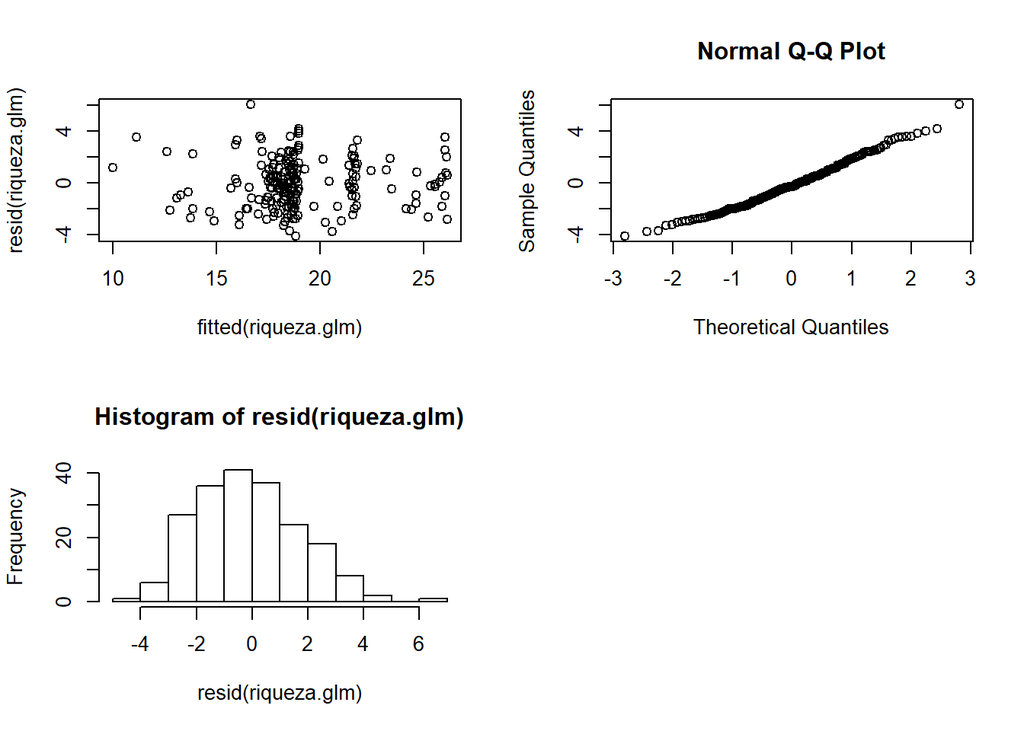

```r
# residuals

par(mfrow=c(2,2))
plot(fitted(riqueza.glm), resid(riqueza.glm))
qqnorm(resid(riqueza.glm))
hist(resid(riqueza.glm))
```

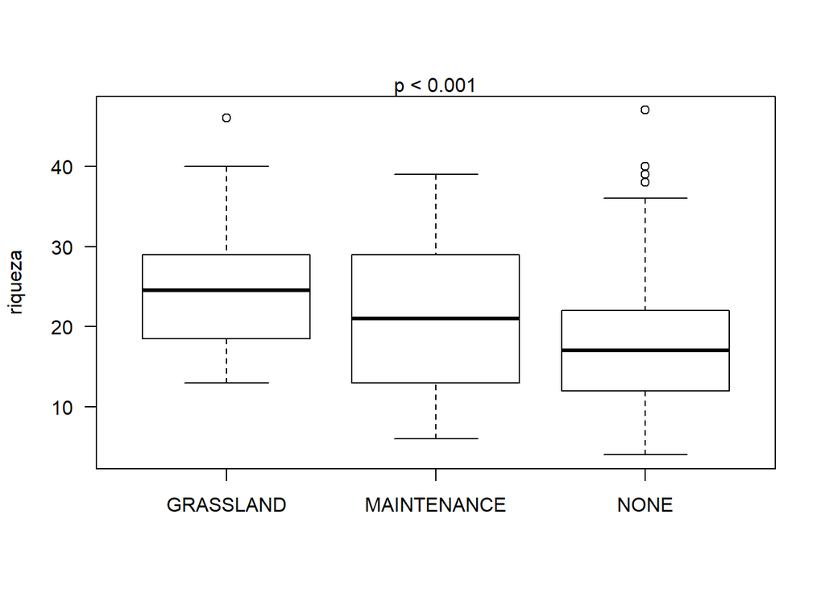

```r
# Boxplot

par(mfrow=c(1,1))
boxplot(Hogweed$Species.richness ~ Hogweed$Land.use, las=1, ylab="riqueza")
mtext(ifelse(riqueza.aov[2,3]<0.001, "p < 0.001",
paste("p = ", round(riqueza.aov[2,3],3))))
```

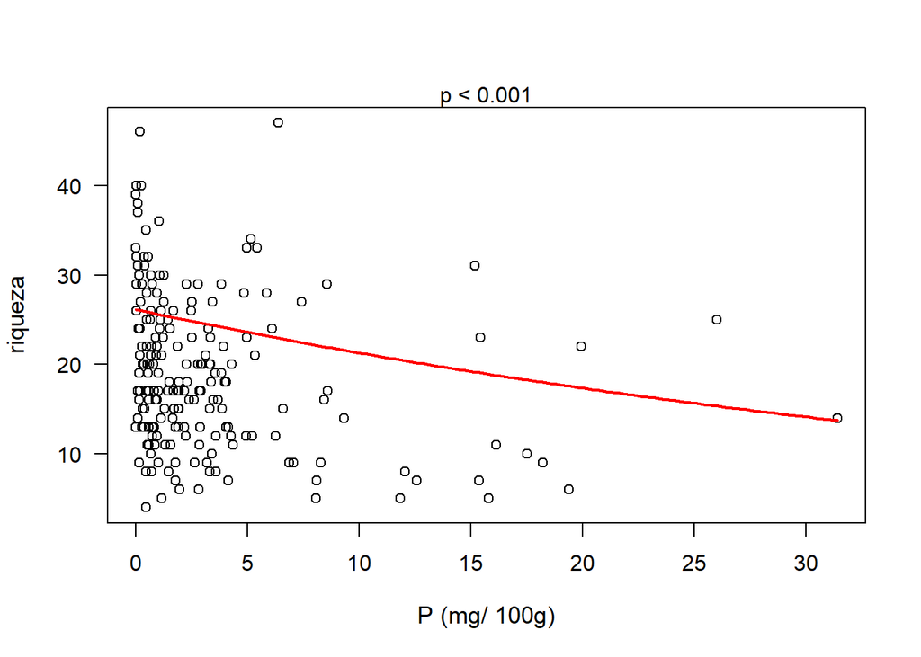

```r
# Scatterplot graph:

b.0.riqueza<- riqueza.glm$coefficients[1]
b.1.riqueza<- riqueza.glm$coefficients[2]
plot(Hogweed$Species.richness ~ Hogweed$P_mg_100g, las=1, ylab="riqueza",
     xlab="P (mg/ 100g)", cex.lab=1.1)
curve(exp(b.0.riqueza + b.1.riqueza*x), add=TRUE, col="red", lwd=2)
mtext(ifelse(riqueza.aov[1,3]<0.001, "p < 0.001",
      paste("p = ", round(riqueza.aov[1,3],3))))
```

Note 3.: the graph construction follows the principles described with LM previously. If you have used a transformation or a link function (other than “=”) in the model, you can include it in the scatterplot syntax, e.g.log (Species.richness). But if you want to plot the original values of the dependent variable, you can do that, too, you just need to back-transform the model predictions to the original scale. In this case you need to transform from the log-scale (used in the Poisson model) to the untransformed species richness used in the scatterplot. That’s why we need the “exp” function in the example above.

#### GLMM (Generalized Linear Mixed Models)

Note 1: Like GLM, the GLMM also require to specify the distribution family (e.g. Poisson), but they don’t accept “quasipoisson” or “quasibinomial”. If poisson doesn’t fit the data because of overdispersion, try negative binomial distribution as explained in GLM section. The syntax is the same: just insert the argument “nb”. Example: basalarea1<- glmer.nb(…, Do not write family name).

GLMM indication: when you have pseudoreplicates. It’s very common in ecological field research to use subplots within each site and these subplots cannot be considered as real replicates. So, a mixed model is appropriate to treat this situation. The definition of what variable is a fixed effect (e.g. in the example below it is “Hogweed.cover” (cover of giant hogweed) and “Habitat.type”) and what is random effect (e.g. in the example below “Study.area”) depends on your research questions and study design. Usually, design factors, such as “block” or “study area” will be random effects, and the variables that you are really interested in (treatments, soil parameters etc.) will be fixed effects. BUT, read about random and fixed effects before constructing your model.

When the command line doesn’t end in the same row, but continues in the next one (like the first command of the GLMM example below), select and press the command of both two lines together. We broke some command lines here to fit in the R script style.

```r
### GLMM usage:

Hogweed <- read.table("Hogweed.csv", header=T, sep=",", dec=".")
head(Hogweed,4)
```

```
##   Plot Study.area  Habitat.type Year Veg.height Veg.cover Species.richness
## 1   s1        VOL ruderal.grass 2002        0.5        70               18
## 2   s2        VOL ruderal.grass 2002        0.7        65               19
## 3   s3        VOL ruderal.grass 2002        0.4        30               16
## 4   s4        VOL ruderal.grass 2002        0.9        90               23
##   Hogweed.height Hogweed.cover Land.use Disturbance Altitude Inclination
## 1            0.9            80     NONE   TREESHRUB  295.653           2
## 2            1.4            65     NONE   TREESHRUB  295.653           2
## 3            1.7            90     NONE   TREESHRUB  295.653           2
## 4            1.0            20     NONE        NONE  292.112           2
##   Exposition N_perc P_mg_100g K_mg_100g
## 1          W   0.19      3.99     22.27
## 2          W   0.19      3.56     12.49
## 3          W   0.19      8.44     39.95
## 4          W   0.12      2.53     12.34
```

```r
library(lme4) # glmer
library(car) # Anova

Richness <- glmer(Species.richness ~ scale(Hogweed.cover) + Habitat.type +
                  (1|Study.area), data=Hogweed, family="poisson")
# Here, the metric predictor variable (Hogweed.cover) was scaled to avoid
# problems in the calculation of the model

summary(Richness)
```

```
## Generalized linear mixed model fit by maximum likelihood (Laplace
##   Approximation) [glmerMod]
##  Family: poisson  ( log )
## Formula: Species.richness ~ scale(Hogweed.cover) + Habitat.type + (1 |
##     Study.area)
##    Data: Hogweed
##
##      AIC      BIC   logLik deviance df.resid
##   1352.4   1375.5   -669.2   1338.4      194
##
## Scaled residuals:
##     Min      1Q  Median      3Q     Max
## -2.6389 -0.9970 -0.1876  0.9007  3.3432
##
## Random effects:
##  Groups     Name        Variance Std.Dev.
##  Study.area (Intercept) 0.08313  0.2883
## Number of obs: 201, groups:  Study.area, 20
##
## Fixed effects:
##                           Estimate Std. Error z value Pr(>|z|)
## (Intercept)                3.17346    0.07660  41.429  < 2e-16 ***
## scale(Hogweed.cover)      -0.07988    0.02052  -3.892 9.94e-05 ***
## Habitat.typeruderal.grass -0.13191    0.05530  -2.385   0.0171 *
## Habitat.typetall.herbs    -0.41489    0.05828  -7.118 1.09e-12 ***
## Habitat.typewasteland     -0.18083    0.07605  -2.378   0.0174 *
## Habitat.typewoodland      -0.50020    0.07356  -6.800 1.05e-11 ***
## ---
## Signif. codes:  0 '***' 0.001 '**' 0.01 '*' 0.05 '.' 0.1 ' ' 1
##
## Correlation of Fixed Effects:
##             (Intr) sc(H.) Hbtt.typr. Hbtt.typt. Hbtt.typws
## scl(Hgwd.c)  0.183
## Hbtt.typrd. -0.424 -0.342
## Hbtt.typtl. -0.415 -0.394  0.567
## Hbtt.typwst -0.279  0.057  0.416      0.316
## Hbtt.typwdl -0.281 -0.042  0.354      0.412      0.269
```

```r
Richness.aov <- Anova(Richness, Type="II")
Richness.aov
```

```
## Analysis of Deviance Table (Type II Wald chisquare tests)
##
## Response: Species.richness
##                       Chisq Df Pr(>Chisq)
## scale(Hogweed.cover) 15.149  1  9.937e-05 ***
## Habitat.type         76.133  4  1.147e-15 ***
## ---
## Signif. codes:  0 '***' 0.001 '**' 0.01 '*' 0.05 '.' 0.1 ' ' 1
```

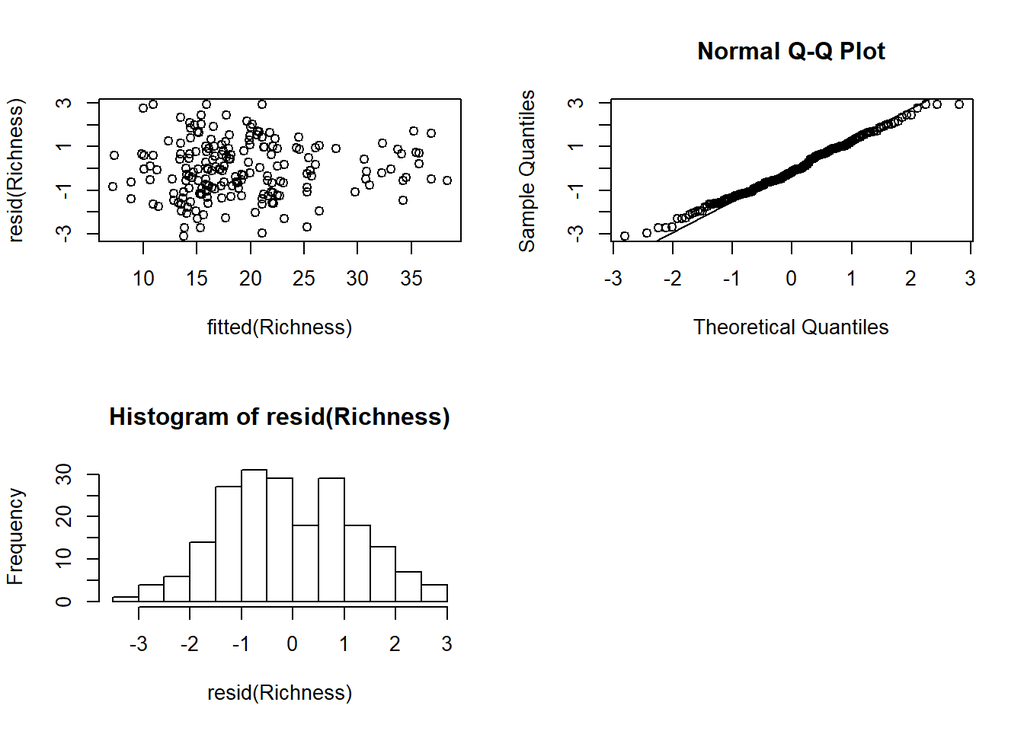

```r
# Residuals

par(mfrow=c(2,2))
plot(fitted(Richness), resid(Richness))
qqnorm(resid(Richness))
qqline(resid(Richness))
hist(resid(Richness))
```

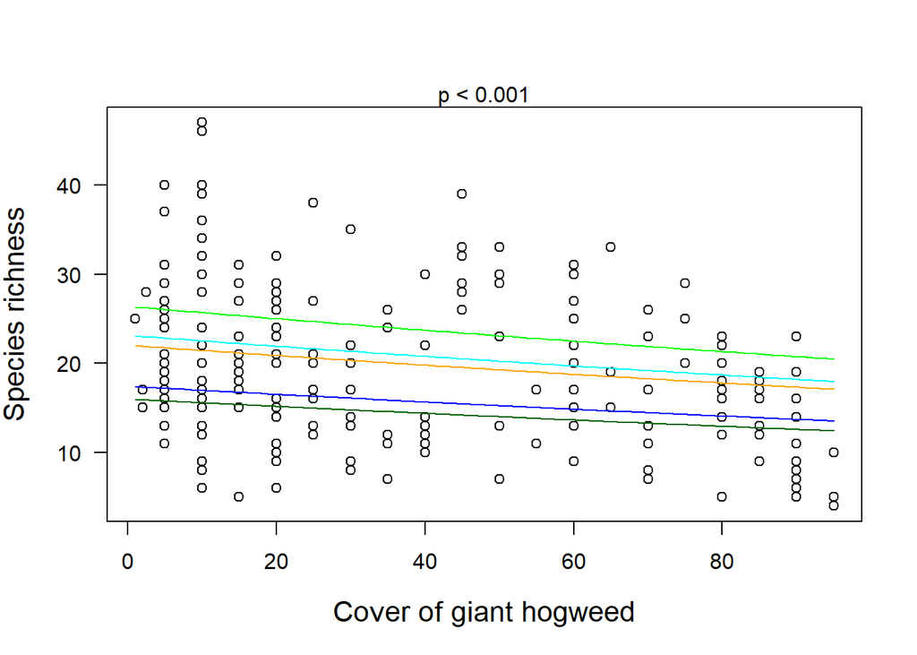

```r
### Scatterplots ###

# With the syntax below you can construct graphs of the relation of the depenent
# variable with a metric predictor variable. This can be done for all levels of
# the categorical predictor variable (here: Habitat.type). To construct the graph
# you can just select and run all of the command lines below.

b0<- coef(summary(Richness))[1,1] # intercept (habitat "agricultural grassland")
b1<- coef(summary(Richness))[2,1] # estimate of hogweed cover
b2<- coef(summary(Richness))[3,1] # estimate of habitat "ruderal grassland"
b3<- coef(summary(Richness))[4,1] # estimate of habitat "tall herbs"
b4<- coef(summary(Richness))[5,1] # estimate of habitat "wasteland"
b5<- coef(summary(Richness))[6,1] # estimate of habitat "woodland"

x11(width=14, height=12)

plot(Hogweed$Species.richness ~ Hogweed$Hogweed.cover, las=1,
     ylab="Species richness", xlab="Cover of giant hogweed", cex.lab=1.3)


# The model that we apply here used poisson distribution which, by default,
# includes a log-link (i.e. log transformation of the dependent variable).
# Thus, we need to use exp() to back-transform the values predicted by the model,
# to the original values of species richness.


mean <- mean(Hogweed$Hogweed.cover)
sd <- sd(Hogweed$Hogweed.cover)

curve(exp(b0 + b1*(x-mean)/sd), add=TRUE, col="green") # curve for agricultural grassland
curve(exp(b0 + b2 + + b1*(x-mean)/sd), add=TRUE, col="cyan") # curve for ruderal grassland
curve(exp(b0 + b3 + + b1*(x-mean)/sd), add=TRUE, col="blue") # curve for tall-herb stands
curve(exp(b0 + b4 + + b1*(x-mean)/sd), add=TRUE, col="orange") # curve for wasteland
curve(exp(b0 + b5 + + b1*(x-mean)/sd), add=TRUE, col="darkgreen") # curve for woodland
mtext(ifelse(Richness.aov[1,3]<0.001, "p < 0.001",
      paste("p = ", round(Richness.aov[1,3],3))))
```

Note 2: the graph construction follows the principles previously described for LM. For further details type the following into your internet search engine: “how construct scatterplots for Mixed models - GLMM? If you have transformed your data, include it in the scatterplot syntax, e.g. log(Data.h3$area basal+1), OR back-transform the predicted values to the original scale (as in the previous example ).

#### GLMM-PQL (Fit GLMM using Penalized Quasi-Likelihood - PQL)

This type of GLMM is used when you need to compute a mixed model for a non-normal dispersion (e.g. poisson, binomial) , it is necessary to use a generalized mixed model that allows the inclusion of correlation structures to account for spatial or temporal effects in the random effects and residuals of the model. The usual functions lmer and glmer of the package lme4 do not allow you to include such correlation structures. Thus, you can adjust Partial Quasi-likelihoods for glmm with the function glmmPQL of the package MASS. The most used spatial and temporal correlation structures for a wide range of situations are, respectively, corExp (exponential spatial correlation structure) and corAR1 (correlation structure of first order for time series) of the package nlme.

The glmmPQL approximates a quasi-likelihood by iterative fitting of (re)weighted linear mixed effects (lme) models based on the fit of Glm. Thus, it estimates the fixed effects parameters by fitting a Glm with its incorporated correlation (variance-covariance) structure. This constructs an Lme model and refits it to re-estimate the variance-covariance structure, utilizing the variance structure from the previous Glm. The iterations continue until the fit improvement is below a threshold or a defined number of iterations has occurred. Therefore, this approach accommodates heterogeneity and spatial/temporal autocorrelation in the model. However, it worth being aware of the fit of PQL generalization for Poisson models, since it commonly performs poorly. If your performance with glmmPQL is poor using the Poisson model, take a look at glmmTMB and glmmADMB packages and functions.For more information on usage of glmmPQL, other models and correlation structures to account for spatial and temporal autocorrelation of residuals, read Dormann et al. (2007).

#### GLMM - PQL: Temporal autocorrelation

Hogweed <- read.table(“Hogweed.csv”, header=T, sep=“,”, dec=“.”) head(Hogweed)

install.packages(“MASS”) install.packages(“nlme”) install.packages(“lme4”)

```r
library(MASS) # PQL Estimation Of Generalized Linear Mixed Models (glmmPQL)
library(nlme) # corAR1 (autocorrelation structure of order 1.
              # For temporal autocorrelation correction)
library(lme4) # glmer

RichnessPQL1 <- glmmPQL(Species.richness ~ scale(Hogweed.cover) +
                         Habitat.type, random=~1| Study.area, data=Hogweed,
                        family="poisson", correlation=corAR1())

summary(RichnessPQL1)
```

```
## Linear mixed-effects model fit by maximum likelihood
##  Data: Hogweed
##   AIC BIC logLik
##    NA  NA     NA
##
## Random effects:
##  Formula: ~1 | Study.area
##         (Intercept) Residual
## StdDev:     0.25502 1.360019
##
## Correlation Structure: AR(1)
##  Formula: ~1 | Study.area
##  Parameter estimate(s):
##      Phi
## 0.212907
## Variance function:
##  Structure: fixed weights
##  Formula: ~invwt
## Fixed effects: Species.richness ~ scale(Hogweed.cover) + Habitat.type
##                               Value  Std.Error  DF  t-value p-value
## (Intercept)                3.179347 0.08077289 176 39.36156  0.0000
## scale(Hogweed.cover)      -0.084974 0.02702220 176 -3.14458  0.0020
## Habitat.typeruderal.grass -0.113853 0.07240569 176 -1.57243  0.1176
## Habitat.typetall.herbs    -0.418886 0.07631617 176 -5.48882  0.0000
## Habitat.typewasteland     -0.154868 0.10070796 176 -1.53779  0.1259
## Habitat.typewoodland      -0.471932 0.09683872 176 -4.87338  0.0000
##  Correlation:
##                           (Intr) sc(H.) Hbtt.typr. Hbtt.typt. Hbtt.typws
## scale(Hogweed.cover)       0.240
## Habitat.typeruderal.grass -0.523 -0.343
## Habitat.typetall.herbs    -0.507 -0.409  0.561
## Habitat.typewasteland     -0.337  0.055  0.408      0.299
## Habitat.typewoodland      -0.357 -0.072  0.368      0.440      0.260
##
## Standardized Within-Group Residuals:
##        Min         Q1        Med         Q3        Max
## -1.9455147 -0.7636449 -0.1452796  0.6615598  2.3691106
##
## Number of Observations: 201
## Number of Groups: 20
```

```r
class(RichnessPQL1)="lme"
anova(object=RichnessPQL1,test="Chisq")
```

```
##                      numDF denDF  F-value p-value
## (Intercept)              1   176 2142.125  <.0001
## scale(Hogweed.cover)     1   176   29.293  <.0001
## Habitat.type             4   176   10.733  <.0001
```

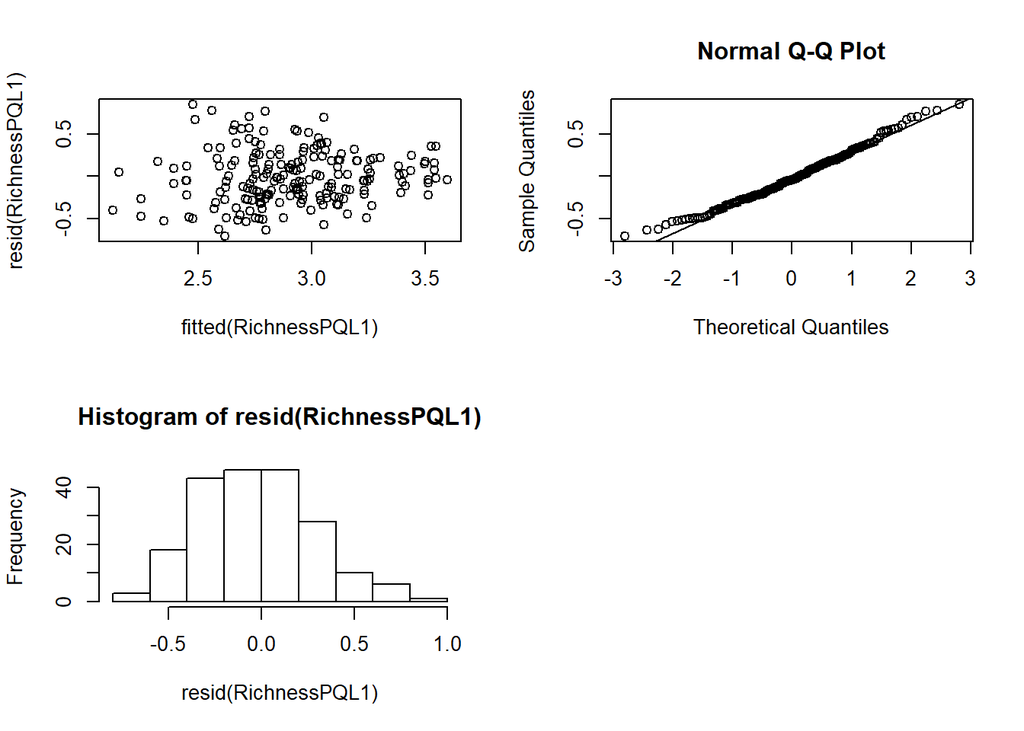

```r
# Residuals

par(mfrow=c(2,2))
plot(fitted(RichnessPQL1), resid(RichnessPQL1))
qqnorm(resid(RichnessPQL1))
qqline(resid(RichnessPQL1))
hist(resid(RichnessPQL1))
```

Note: Fitting a “lme” class for the glmmPQL is not recommended as the most appropriate way to acquire p-values from anova of the model above. Here we can compute a lme model for the same variables of the glmmPQL model and compare the outcomes of the anova of both models. Despite lme requiring data to conform to assumptions of normality, we can use this model for a dataset where Y is discrete (Poisson), once the residual fit is as close as possible to normal, which were already complied using the residuals of glmmPQL model.. Let’s see.

```r
RichnessPQL1.2 <- lme(Species.richness ~ scale(Hogweed.cover) +
                         Habitat.type, random=~1| Study.area,
                         data=Hogweed, correlation = corAR1())

summary(RichnessPQL1.2)
```

```
## Linear mixed-effects model fit by REML
##  Data: Hogweed
##        AIC      BIC    logLik
##   1316.934 1346.391 -649.4672
##
## Random effects:
##  Formula: ~1 | Study.area
##         (Intercept) Residual
## StdDev:    5.656911 5.910775
##
## Correlation Structure: AR(1)
##  Formula: ~1 | Study.area
##  Parameter estimate(s):
##       Phi
## 0.1828919
## Fixed effects: Species.richness ~ scale(Hogweed.cover) + Habitat.type
##                               Value Std.Error  DF   t-value p-value
## (Intercept)               24.741612 1.7117346 176 14.454117  0.0000
## scale(Hogweed.cover)      -1.420397 0.4884303 176 -2.908086  0.0041
## Habitat.typeruderal.grass -2.853129 1.4641553 176 -1.948652  0.0529
## Habitat.typetall.herbs    -7.851275 1.4603586 176 -5.376265  0.0000
## Habitat.typewasteland     -3.446089 2.0679085 176 -1.666461  0.0974
## Habitat.typewoodland      -9.293588 1.8178651 176 -5.112364  0.0000
##  Correlation:
##                           (Intr) sc(H.) Hbtt.typr. Hbtt.typt. Hbtt.typws
## scale(Hogweed.cover)       0.200
## Habitat.typeruderal.grass -0.517 -0.332
## Habitat.typetall.herbs    -0.529 -0.417  0.618
## Habitat.typewasteland     -0.345  0.046  0.412      0.352
## Habitat.typewoodland      -0.398 -0.081  0.431      0.506      0.317
##
## Standardized Within-Group Residuals:
##        Min         Q1        Med         Q3        Max
## -2.0616284 -0.7119363 -0.1222464  0.6971461  2.5063006
##
## Number of Observations: 201
## Number of Groups: 20
```

```r
anova(RichnessPQL1.2)
```

```
##                      numDF denDF   F-value p-value
## (Intercept)              1   176 212.89541  <.0001
## scale(Hogweed.cover)     1   176  27.24646  <.0001
## Habitat.type             4   176  10.43767  <.0001
```

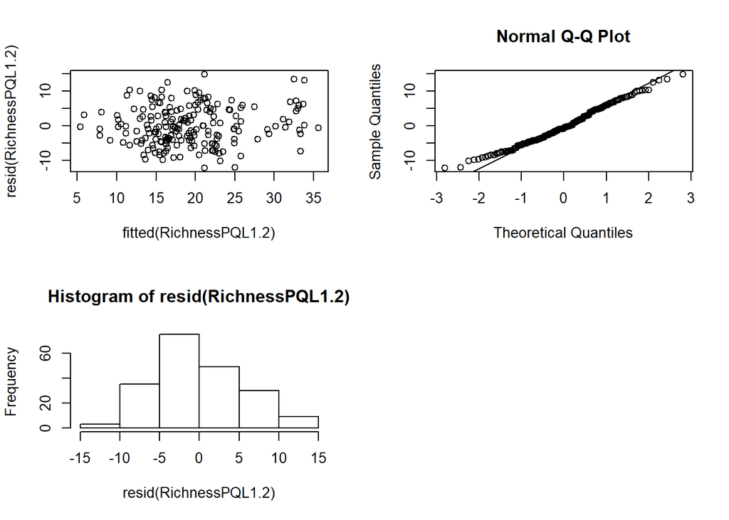

```r
# Residuals

par(mfrow=c(2,2))
plot(fitted(RichnessPQL1.2), resid(RichnessPQL1.2))
qqnorm(resid(RichnessPQL1.2))
qqline(resid(RichnessPQL1.2))
hist(resid(RichnessPQL1.2))
```

Overall, we can see that both the lme and glmmPQL models in this example display well-fitting residuals and the anova outcomes of both provide very similar results.

#### Wald Test for GLMM-PQL

```r
RichnessPQL1 <- glmmPQL(Species.richness ~ scale(Hogweed.cover) +
                          Habitat.type, random=~1| Study.area, data=Hogweed,
                        family="poisson", correlation=corAR1())
```

```
## iteration 1
```

```
## iteration 2
```

```
## iteration 3
```

```r
summary(RichnessPQL1)
```

```
## Linear mixed-effects model fit by maximum likelihood
##  Data: Hogweed
##   AIC BIC logLik
##    NA  NA     NA
##
## Random effects:
##  Formula: ~1 | Study.area
##         (Intercept) Residual
## StdDev:     0.25502 1.360019
##
## Correlation Structure: AR(1)
##  Formula: ~1 | Study.area
##  Parameter estimate(s):
##      Phi
## 0.212907
## Variance function:
##  Structure: fixed weights
##  Formula: ~invwt
## Fixed effects: Species.richness ~ scale(Hogweed.cover) + Habitat.type
##                               Value  Std.Error  DF  t-value p-value
## (Intercept)                3.179347 0.08077289 176 39.36156  0.0000
## scale(Hogweed.cover)      -0.084974 0.02702220 176 -3.14458  0.0020
## Habitat.typeruderal.grass -0.113853 0.07240569 176 -1.57243  0.1176
## Habitat.typetall.herbs    -0.418886 0.07631617 176 -5.48882  0.0000
## Habitat.typewasteland     -0.154868 0.10070796 176 -1.53779  0.1259
## Habitat.typewoodland      -0.471932 0.09683872 176 -4.87338  0.0000
##  Correlation:
##                           (Intr) sc(H.) Hbtt.typr. Hbtt.typt. Hbtt.typws
## scale(Hogweed.cover)       0.240
## Habitat.typeruderal.grass -0.523 -0.343
## Habitat.typetall.herbs    -0.507 -0.409  0.561
## Habitat.typewasteland     -0.337  0.055  0.408      0.299
## Habitat.typewoodland      -0.357 -0.072  0.368      0.440      0.260
##
## Standardized Within-Group Residuals:
##        Min         Q1        Med         Q3        Max
## -1.9455147 -0.7636449 -0.1452796  0.6615598  2.3691106
##
## Number of Observations: 201
## Number of Groups: 20
```

Since the main statistic of interest is the Wald approach (t for PQL) for the fixed effects parameters, we can firstly fit a crude Wald. The summary of the model gives us crude (Wald) estimates of the p-values for each individual parameter:

```r
coef(summary(RichnessPQL1))
```

```
##                                 Value  Std.Error  DF   t-value
## (Intercept)                3.17934701 0.08077289 176 39.361559
## scale(Hogweed.cover)      -0.08497357 0.02702220 176 -3.144583
## Habitat.typeruderal.grass -0.11385291 0.07240569 176 -1.572430
## Habitat.typetall.herbs    -0.41888568 0.07631617 176 -5.488820
## Habitat.typewasteland     -0.15486750 0.10070796 176 -1.537788
## Habitat.typewoodland      -0.47193166 0.09683872 176 -4.873378
##                                p-value
## (Intercept)               3.647255e-89
## scale(Hogweed.cover)      1.952741e-03
## Habitat.typeruderal.grass 1.176467e-01
## Habitat.typetall.herbs    1.393556e-07
## Habitat.typewasteland     1.258963e-01
## Habitat.typewoodland      2.436558e-06
```

One could be interested in the investigation of the main effects as a whole. Thus, we use the function “wald.test” of the package aod in order test the influence of the factor as whole using the Wald Z and X² (Wald Chi-squared) test, which is an approach analogous to an ANOVA. In function “wald.test” the following parameters are used:

You define the terms by designating the order in which the coefficients of interest appear in the summary of the model. For instance, the predictor scale(Hogweed.cover) is the second coefficient after the intercept and Habitat.typewoodland is sixth and last. If we are interested in the main effects of the groups of parameters as whole, then we write ‘Terms=2:6’. It is important to notice that the Wald X² test is suitable only in the absence of overdispersion in the model. When the model is overdispersed the suitable approach is to use Wald F and X² tests.

```r
# install.packages("aod")
library(aod)

wald<-wald.test(b=fixef(RichnessPQL1),
                  Sigma=vcov(RichnessPQL1),Terms=2:6)

wald
```

```
## Wald test:
## ----------
##
## Chi-squared test:
## X2 = 74.4, df = 5, P(> X2) = 1.2e-14
```

The global p-value of Wald confirms the overall significant effect of the numeric (Hogweed.cover) and categorical (Habitat.type) predictors, as found in the other models (glmmPQL and lme), with Species.richness as response variable.

To assess the confidence intervals for model estimates based on Wald statistics.

```r
library(gmodels)
ci(RichnessPQL1, method="Wald")
```

```
##                              Estimate   CI lower    CI upper Std. Error
## (Intercept)                3.17934701  3.0199389  3.33875510 0.08077289
## scale(Hogweed.cover)      -0.08497357 -0.1383028 -0.03164432 0.02702220
## Habitat.typeruderal.grass -0.11385291 -0.2567480  0.02904221 0.07240569
## Habitat.typetall.herbs    -0.41888568 -0.5694983 -0.26827310 0.07631617
## Habitat.typewasteland     -0.15486750 -0.3536181  0.04388312 0.10070796
## Habitat.typewoodland      -0.47193166 -0.6630462 -0.28081712 0.09683872
##                            DF      p-value
## (Intercept)               176 3.647255e-89
## scale(Hogweed.cover)      176 1.952741e-03
## Habitat.typeruderal.grass 176 1.176467e-01
## Habitat.typetall.herbs    176 1.393556e-07
## Habitat.typewasteland     176 1.258963e-01
## Habitat.typewoodland      176 2.436558e-06
```

#### GLMM - PQL: Spatial autocorrelation

```r
BIOVEG <- read.table("BIOVEG3.csv", header=T, sep=",", dec=".")
head(BIOVEG, 4)
```

```
##           type Plot  Site                Species Richness Diameter
## 1 Semidecidual p001 AREA1 Alchornea_triplinervia        8    27.12
## 2 Semidecidual p002 AREA1     Amaioua_intermedia       10    39.15
## 3 Semidecidual p003 AREA1          Aniba_firmula       10    33.93
## 4 Semidecidual p004 AREA1          Annona_cacans       10    40.43
##   Mean_diameter Basal.area Abundance Precipitation_mean Temperature_mean
## 1         6.357      0.058         7               1250             24.4
## 2         6.524      0.120        12               1250             24.4
## 3         6.632      0.090        10               1250             24.4
## 4         6.626      0.128        19               1250             24.4
##   Mortality Recruitment local.x local.y  utm.x   utm.y local.utm.x
## 1      6.94       14.34       0       0 747923 7807727      747923
## 2      2.74        6.94     -10       0 747923 7807727      747913
## 3      1.71        2.35     -20       0 747923 7807727      747903
## 4      1.60        2.47     -30       0 747923 7807727      747893
##   local.utm.y
## 1     7807727
## 2     7807727
## 3     7807727
## 4     7807727
```

```r
library(MASS) # PQL Estimation Of Generalized Linear Mixed Models (glmmPQL)
library(nlme) # corExp (autocorrelation structure of order 1.
              # For temporal autocorrelation correction)
library(lme4) # glmer


RichnessPQL2 <- glmmPQL(Richness ~ Mortality + Recruitment, random=~1|
                          Site, data=BIOVEG, family=poisson(),
                          correlation = corExp())
```

```
## iteration 1
```

```
## iteration 2
```

```
## iteration 3
```

```r
summary(RichnessPQL2)
```

```
## Linear mixed-effects model fit by maximum likelihood
##  Data: BIOVEG
##   AIC BIC logLik
##    NA  NA     NA
##
## Random effects:
##  Formula: ~1 | Site
##          (Intercept) Residual
## StdDev: 2.513287e-05 1.568849
##
## Correlation Structure: Exponential spatial correlation
##  Formula: ~1 | Site
##  Parameter estimate(s):
##    range
## 2.114817
## Variance function:
##  Structure: fixed weights
##  Formula: ~invwt
## Fixed effects: Richness ~ Mortality + Recruitment
##                  Value  Std.Error  DF  t-value p-value
## (Intercept)  2.7193377 0.07676437 145 35.42448  0.0000
## Mortality   -0.0076205 0.00877996 145 -0.86795  0.3869
## Recruitment  0.0044188 0.01109908 145  0.39812  0.6911
##  Correlation:
##             (Intr) Mrtlty
## Mortality   -0.290
## Recruitment -0.366 -0.075
##
## Standardized Within-Group Residuals:
##         Min          Q1         Med          Q3         Max
## -1.68788217 -0.78368147 -0.02639946  0.48572389  4.85960190
##
## Number of Observations: 150
## Number of Groups: 3
```

```r
class(RichnessPQL2)="lme"
anova(RichnessPQL2,test="Chisq")
```

```
##             numDF denDF   F-value p-value
## (Intercept)     1   145 1629.6022  <.0001
## Mortality       1   145    0.7061  0.4021
## Recruitment     1   145    0.1585  0.6911
```

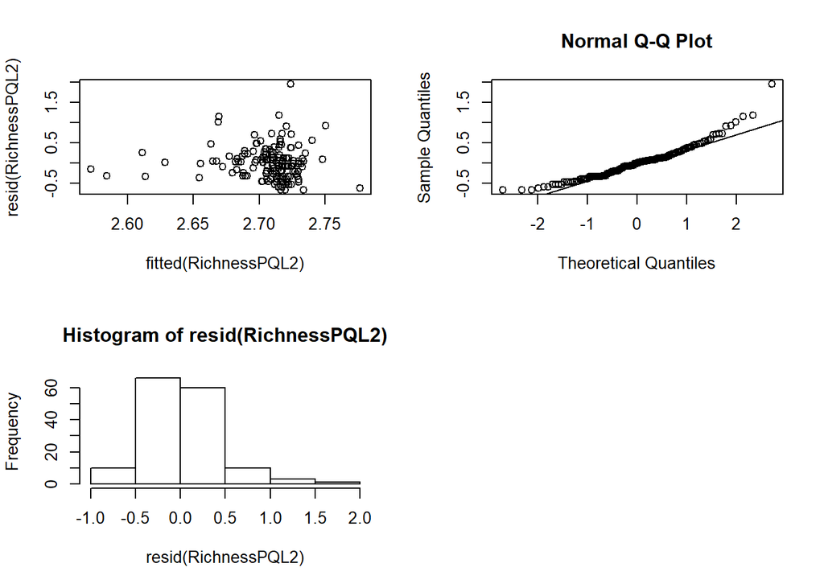

```r
# Residuals

par(mfrow=c(2,2))
plot(fitted(RichnessPQL2), resid(RichnessPQL2))
qqnorm(resid(RichnessPQL2))
qqline(resid(RichnessPQL2))
hist(resid(RichnessPQL2))
```

```r
RichnessPQL2.1 <- glm.nb(Richness ~ Mortality + Recruitment, data=BIOVEG)
theta<-RichnessPQL2.1$theta
```

```r
RichnessPQL2.1.1 <- glmmPQL(Richness ~ Mortality + Recruitment, random=~1|
                          Site, data=BIOVEG, family=quasipoisson(),
                        correlation = corExp())
```

```
## iteration 1
```

```
## iteration 2
```

```
## iteration 3
```

```r
summary(RichnessPQL2.1.1)
```

```
## Linear mixed-effects model fit by maximum likelihood
##  Data: BIOVEG
##   AIC BIC logLik
##    NA  NA     NA
##
## Random effects:
##  Formula: ~1 | Site
##          (Intercept) Residual
## StdDev: 2.513287e-05 1.568849
##
## Correlation Structure: Exponential spatial correlation
##  Formula: ~1 | Site
##  Parameter estimate(s):
##    range
## 2.114817
## Variance function:
##  Structure: fixed weights
##  Formula: ~invwt
## Fixed effects: Richness ~ Mortality + Recruitment
##                  Value  Std.Error  DF  t-value p-value
## (Intercept)  2.7193377 0.07676437 145 35.42448  0.0000
## Mortality   -0.0076205 0.00877996 145 -0.86795  0.3869
## Recruitment  0.0044188 0.01109908 145  0.39812  0.6911
##  Correlation:
##             (Intr) Mrtlty
## Mortality   -0.290
## Recruitment -0.366 -0.075
##
## Standardized Within-Group Residuals:
##         Min          Q1         Med          Q3         Max
## -1.68788217 -0.78368147 -0.02639946  0.48572389  4.85960190
##
## Number of Observations: 150
## Number of Groups: 3
```

```r
class(RichnessPQL2.1.1)="lme"
anova(object=RichnessPQL2.1.1,test="Chisq")
```

```
##             numDF denDF   F-value p-value
## (Intercept)     1   145 1629.6022  <.0001
## Mortality       1   145    0.7061  0.4021
## Recruitment     1   145    0.1585  0.6911
```

Similar to the first example of glmmPQL above, we run a lme model for the same set of variables and compare the residuals and anova outcomes of both models. Despite the fact that lme assumes a normal distribution, we can still consider this model if the residuals reasonably conform with a normal fit.

```r
RichnessPQL2.2 <- lme(Richness ~ Mortality + Recruitment, random=~1|
                        Site, data=BIOVEG, correlation
                      = corExp())
summary(RichnessPQL2.2)
```

```
## Linear mixed-effects model fit by REML
##  Data: BIOVEG
##        AIC      BIC    logLik
##   909.0265 926.9691 -448.5133
##
## Random effects:
##  Formula: ~1 | Site
##         (Intercept) Residual
## StdDev: 0.003170964 6.205825
##
## Correlation Structure: Exponential spatial correlation
##  Formula: ~1 | Site
##  Parameter estimate(s):
##   range
## 2.19089
## Fixed effects: Richness ~ Mortality + Recruitment
##                 Value Std.Error  DF   t-value p-value
## (Intercept) 15.147875 1.1779626 145 12.859385  0.0000
## Mortality   -0.113682 0.1260718 145 -0.901720  0.3687
## Recruitment  0.072715 0.1686360 145  0.431194  0.6670
##  Correlation:
##             (Intr) Mrtlty
## Mortality   -0.298
## Recruitment -0.350 -0.076
##
## Standardized Within-Group Residuals:
##         Min          Q1         Med          Q3         Max
## -1.67557693 -0.75056004 -0.02212395  0.47904130  4.79686539
##
## Number of Observations: 150
## Number of Groups: 3
```

```r
anova(RichnessPQL2.2)
```

```
##             numDF denDF   F-value p-value
## (Intercept)     1   145 209.95041  <.0001
## Mortality       1   145   0.75942   0.385
## Recruitment     1   145   0.18593   0.667
```

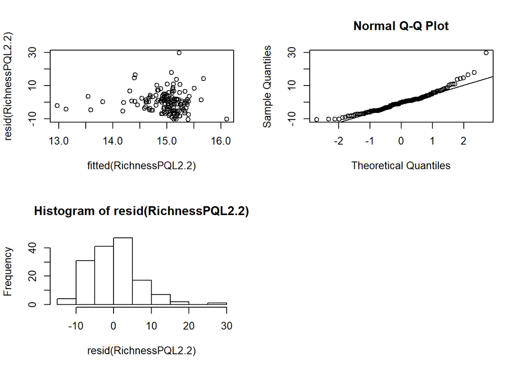

```r
# Residuals

par(mfrow=c(2,2))
plot(fitted(RichnessPQL2.2), resid(RichnessPQL2.2))
qqnorm(resid(RichnessPQL2.2))
qqline(resid(RichnessPQL2.2))
hist(resid(RichnessPQL2.2))
```

The anova output of the lme model, similar to those of the glmmPQL with Richness as response variable, shows that none of the predictors are significantly related to this response variable. However, the residual fit of this lme model is also not as good as those of the glmmPQL models for this response variable. Thus, we can try to log-transform Richness, though log transformations of discrete data are largely not advised and their use demands a cautious approach.

```r
RichnessPQL2.2.2 <- lme(log(Richness) ~ Mortality + Recruitment, random=~1|
                        Site, data=BIOVEG, correlation
                      = corExp())
summary(RichnessPQL2.2.2)
```

```
## Linear mixed-effects model fit by REML
##  Data: BIOVEG
##       AIC      BIC    logLik
##   121.274 139.2166 -54.63701
##
## Random effects:
##  Formula: ~1 | Site
##         (Intercept)  Residual
## StdDev:  0.04515893 0.4084216
##
## Correlation Structure: Exponential spatial correlation
##  Formula: ~1 | Site
##  Parameter estimate(s):
##    range
## 1.907718
## Fixed effects: log(Richness) ~ Mortality + Recruitment
##                  Value  Std.Error  DF  t-value p-value
## (Intercept)  2.6515169 0.07939254 145 33.39756  0.0000
## Mortality   -0.0092208 0.00874206 145 -1.05476  0.2933
## Recruitment  0.0025622 0.01170855 145  0.21883  0.8271
##  Correlation:
##             (Intr) Mrtlty
## Mortality   -0.308
## Recruitment -0.359 -0.074
##
## Standardized Within-Group Residuals:
##        Min         Q1        Med         Q3        Max
## -2.5263531 -0.7349958  0.1569121  0.6254959  2.7853229
##
## Number of Observations: 150
## Number of Groups: 3
```

```r
anova(RichnessPQL2.2.2)
```

```
##             numDF denDF   F-value p-value
## (Intercept)     1   145 1446.6712  <.0001
## Mortality       1   145    1.0846  0.2994
## Recruitment     1   145    0.0479  0.8271
```

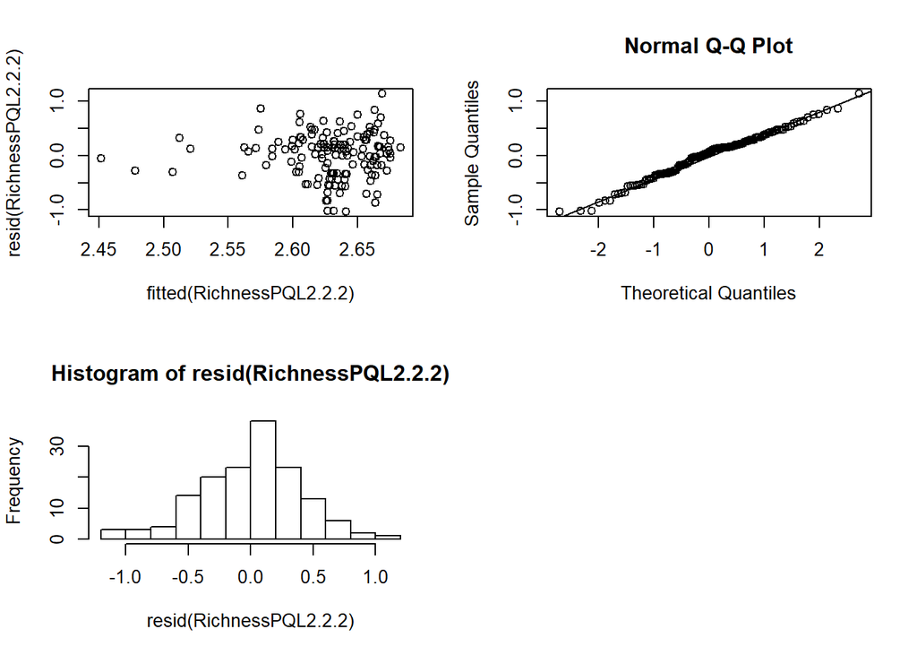

```r
# Residuals

par(mfrow=c(2,2))
plot(fitted(RichnessPQL2.2.2), resid(RichnessPQL2.2.2))
qqnorm(resid(RichnessPQL2.2.2))
qqline(resid(RichnessPQL2.2.2))
hist(resid(RichnessPQL2.2.2))
```

For this lme model, the log transformation of Richness worked well. The residuals are better fitted and the anova output maintains non-significance for the predictor variables, similar to the previous glmmPQL and lme models. This suggests that there is no great distortion of the empirical condition of the data in the model after the log transformation.

#### Wald Test

Now, let’s compute the Wald test for the model “RichnessPQL2.1.1”

```r
summary(RichnessPQL2.1.1)
```

```
## Linear mixed-effects model fit by maximum likelihood
##  Data: BIOVEG
##   AIC BIC logLik
##    NA  NA     NA
##
## Random effects:
##  Formula: ~1 | Site
##          (Intercept) Residual
## StdDev: 2.513287e-05 1.568849
##
## Correlation Structure: Exponential spatial correlation
##  Formula: ~1 | Site
##  Parameter estimate(s):
##    range
## 2.114817
## Variance function:
##  Structure: fixed weights
##  Formula: ~invwt
## Fixed effects: Richness ~ Mortality + Recruitment
##                  Value  Std.Error  DF  t-value p-value
## (Intercept)  2.7193377 0.07676437 145 35.42448  0.0000
## Mortality   -0.0076205 0.00877996 145 -0.86795  0.3869
## Recruitment  0.0044188 0.01109908 145  0.39812  0.6911
##  Correlation:
##             (Intr) Mrtlty
## Mortality   -0.290
## Recruitment -0.366 -0.075
##
## Standardized Within-Group Residuals:
##         Min          Q1         Med          Q3         Max
## -1.68788217 -0.78368147 -0.02639946  0.48572389  4.85960190
##
## Number of Observations: 150
## Number of Groups: 3
```

```r
wald2<-wald.test(b=fixef(RichnessPQL2.1.1),
                Sigma=vcov(RichnessPQL2.1.1),Terms=2:3)

wald2
```

```
## Wald test:
## ----------
##
## Chi-squared test:
## X2 = 0.88, df = 2, P(> X2) = 0.64
```

The global p-value of Wald confirms the non-significant effects of the predictors (Mortality and Recruitment) as found in the previous glmmPQL and lme models for this set of variables.

```r
# Confidence Interval under Wald fit.

ci(RichnessPQL2.1.1, method=Wald)
```

```
##                 Estimate    CI lower    CI upper  Std. Error  DF
## (Intercept)  2.719337688  2.56761601 2.871059367 0.076764373 145
## Mortality   -0.007620525 -0.02497375 0.009732702 0.008779955 145
## Recruitment  0.004418759 -0.01751812 0.026355633 0.011099076 145
##                  p-value
## (Intercept) 2.826205e-73
## Mortality   3.868582e-01
## Recruitment 6.911276e-01
```

##### Useful links and examples:

https://rpubs.com/bbolker/glmmchapter

http://www.flutterbys.com.au/stats/tut/tut11.2a.html

https://bbolker.github.io/mixedmodels-misc/glmmFAQ.html

https://bbolker.github.io/mixedmodels-misc/ecostats_chap.html

https://www.rdocumentation.org/packages/MASS/versions/7.3-47/topics/glmmPQL

Recommended Reading:

Box, G.E.P., Jenkins, G.M., and Reinsel G.C. (1994) “Time Series Analysis: Forecasting and Control”, 3rd Edition, Holden-Day.

Pinheiro, J.C., and Bates, D.M. (2000) “Mixed-Effects Models in S and S-PLUS”, Springer, esp. pp. 235, 397.

Cressie, N.A.C. (1993), “Statistics for Spatial Data”, J. Wiley & Sons.

Venables, W.N. and Ripley, B.D. (2002) “Modern Applied Statistics with S”, 4th Edition, Springer-Verlag.

#### LOGISTIC REGRESSION

Hypothesis test: in a period of 5 years do the continuous variables (mean diameter and mean precipitation) affect the likelihood of tree recruitment, i.e., survival, growth and achieve a minimum diameter criteria (e.g. > 15 cm). That is, we want to know if in a five years-period of forest monitoring, do two continuous variables (Mean_diameter + Precipitation_mean) and one categorical (type of vegetation) determine the success of a trees individual likelihood of recruitment (0 indicates the absence of recruitment in a subplot and 1 the presence).

```r
Lreg <- read.table("Logit2.csv", header=T, sep=";", dec=".")
head(Lreg,4)
```

```
##          type1  Site Mean_diameter Precipitation_mean Rec.binar
## 1 Ombrophilous AREA1        11.657               1142         1
## 2 Ombrophilous AREA1        13.793               1142         1
## 3 Ombrophilous AREA1        17.928               1142         1
## 4 Ombrophilous AREA1        12.212               1142         1
```

```r
Recrut.binar<- glm(Rec.binar ~ Mean_diameter + Precipitation_mean +
                                type1, data=Lreg,family="binomial")
Recrut.binar
```

```
##
## Call:  glm(formula = Rec.binar ~ Mean_diameter + Precipitation_mean +
##     type1, family = "binomial", data = Lreg)
##
## Coefficients:
##        (Intercept)       Mean_diameter  Precipitation_mean
##           4.431746           -0.143722           -0.001657
##  type1Ombrophilous   type1Semideciduos
##          -0.825271           -0.120710
##
## Degrees of Freedom: 449 Total (i.e. Null);  445 Residual
## Null Deviance:       586.9
## Residual Deviance: 553.5     AIC: 563.5
```

#### LRT (likelihood ratio test)

To test the overall model fit and hypothesis

LRT compares the full model with a reduced model where the explanatory variables of interest are omitted and provides p-values of the tests calculated using Chi-squared distribution.

```r
Rec.bin.reduced<- glm(Rec.binar ~ 1, data=Lreg, family="binomial")
anova(Rec.bin.reduced,Recrut.binar, test="Chisq")
```

```
## Analysis of Deviance Table
##
## Model 1: Rec.binar ~ 1
## Model 2: Rec.binar ~ Mean_diameter + Precipitation_mean + type1
##   Resid. Df Resid. Dev Df Deviance  Pr(>Chi)
## 1       449     586.92
## 2       445     553.52  4     33.4 9.893e-07 ***
## ---
## Signif. codes:  0 '***' 0.001 '**' 0.01 '*' 0.05 '.' 0.1 ' ' 1
```

The LRT is 33.399 with a p-value 9.895e-07. Thus, we have strong evidence, based on high significance, that there is influence of some of the predictors in the success or failure of tree recruitment.

Perform tests on the individual regression parameters:

```r
summary(Recrut.binar)
```

```
##
## Call:
## glm(formula = Rec.binar ~ Mean_diameter + Precipitation_mean +
##     type1, family = "binomial", data = Lreg)
##
## Deviance Residuals:
##     Min       1Q   Median       3Q      Max
## -1.8080  -1.2327   0.7476   0.9216   1.9004
##
## Coefficients:
##                     Estimate Std. Error z value Pr(>|z|)
## (Intercept)         4.431746   1.742508   2.543  0.01098 *
## Mean_diameter      -0.143722   0.035671  -4.029  5.6e-05 ***
## Precipitation_mean -0.001657   0.001402  -1.182  0.23730
## type1Ombrophilous  -0.825271   0.314016  -2.628  0.00859 **
## type1Semideciduos  -0.120710   0.280880  -0.430  0.66737
## ---
## Signif. codes:  0 '***' 0.001 '**' 0.01 '*' 0.05 '.' 0.1 ' ' 1
##
## (Dispersion parameter for binomial family taken to be 1)
##
##     Null deviance: 586.92  on 449  degrees of freedom
## Residual deviance: 553.52  on 445  degrees of freedom
## AIC: 563.52
##
## Number of Fisher Scoring iterations: 4
```

We can check for significance of influence from the predictors by executing a test for the full model.

```r
anova(Recrut.binar, test="Chisq")
```

```
## Analysis of Deviance Table
##
## Model: binomial, link: logit
##
## Response: Rec.binar
##
## Terms added sequentially (first to last)
##
##
##                    Df Deviance Resid. Df Resid. Dev  Pr(>Chi)
## NULL                                 449     586.92
## Mean_diameter       1  23.8193       448     563.10 1.058e-06 ***
## Precipitation_mean  1   0.1662       447     562.93  0.683539
## type1               2   9.4142       445     553.52  0.009031 **
## ---
## Signif. codes:  0 '***' 0.001 '**' 0.01 '*' 0.05 '.' 0.1 ' ' 1
```

```r
# To compute the odds of successful tree recruitment as a function of mean diameter
# and ombrophilous type

exp(coef(Recrut.binar))
```

```
##        (Intercept)      Mean_diameter Precipitation_mean
##         84.0780806          0.8661288          0.9983448
##  type1Ombrophilous  type1Semideciduos
##          0.4381162          0.8862912
```

```r
## To create a 95% confidence interval for the estimate, type:

exp(confint.default(Recrut.binar))
```

```
##                        2.5 %       97.5 %
## (Intercept)        2.7634844 2558.0472670
## Mean_diameter      0.8076423    0.9288507
## Precipitation_mean 0.9956056    1.0010915
## type1Ombrophilous  0.2367547    0.8107368
## type1Semideciduos  0.5110827    1.5369570
```

We see that the odds ratio corresponding to mean diameter is 0.87 (95% CI: (0.80, 0.92)) and Ombrophilous is 0.43 (95% CI: (0.23, 0.811))

To use the fitted logistic regression curve to estimate the predictive power and accuracy of the model. The most commonly used way to check the predictive ability of a logistic model is to fit the ROC curve and its AUC (area under the curve), which are typical performance measurements for a binary classifier. The ROC is a curve which plots the true positive rate (TPR) against the false positive rate (FPR) at various threshold settings, whereas the AUC is the area under the ROC curve. A commonly used rule to assess the robustness of predictive power of the model, is to consider a good predictive ability when AUC is closer to 1 (1 is ideal) than to 0.5.

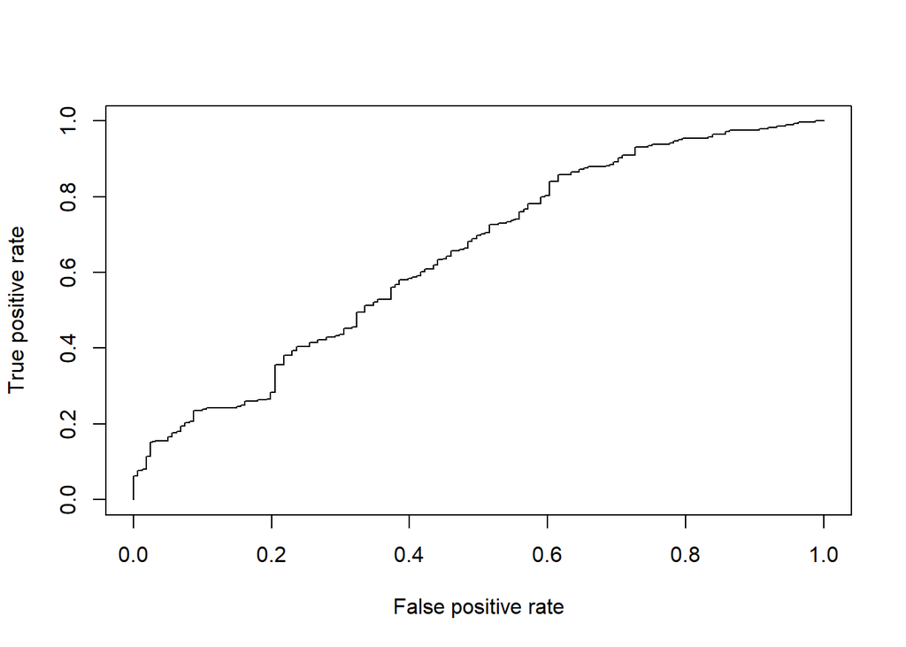

```r
# install.packages("ROCR")
library(ROCR)

p <- predict(Recrut.binar, type="response") # predict scorees
pr <- prediction(p, Lreg$Rec.binar)
prf <- performance(pr, measure = "tpr", x.measure = "fpr")
plot(prf)
```

```r
auc <- performance(pr, measure = "auc")
auc <- auc@y.values[[1]]
auc
```

```
## [1] 0.6462206
```

install.packages(“InformationValue”) # To plot ROC curve

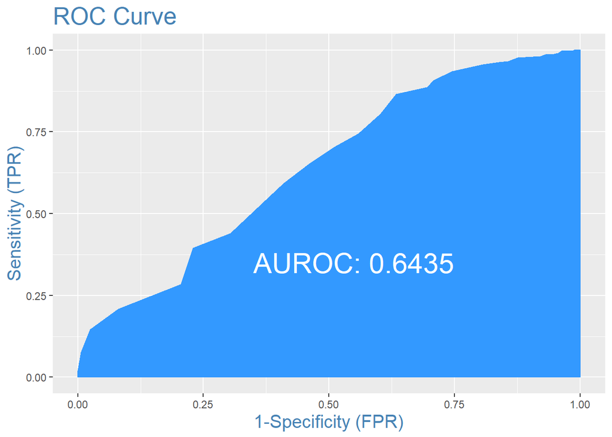

```r
library(InformationValue)

P<- plotROC(Lreg$Rec.binar, p)
```

Here we got a reasonable predictive accuracy (0.64), but it could be better (e.g. > 0.70).

#### Moran’s I: spatial autocorrelation test

Spatial autocorrelation refers to the correlation between the values of a variable due their proximity in geographical space. This violates the assumption that they are from independent observations.

The function “moransI” of the package “lctools” allows us to estimate the local spatial correlation of the residuals from a linear model.

In order to execute the classical Moran’s I test with this function, we first must calculate and provide metric coordinates, such as UTM coordinates, for each row of data. Firstly you must convert the geographical coordinates belonging to your data to UTM. After this, if you are using subplots (e.g. treatment with 50 subplots of 10 meters per 10 meters) you must add the distance of each subplot from the reference point of the site to the UTM coordinates of the site. This is done separately for X direction (East-West) and Y direction (North-South). If the reference point is the South-West corner of the site, you add the distances of the subplot in W-E and S-N direction to the site coordinates (e.g. 10 m and 30 m). But, if the reference point is the North-East corner, you subtract the distances from the site coordinates.

Each row of your data will contain real coordinates based on the sample units (here represented by subplot) and you will be able to estimate spatial autocorrelation in your linear model.

It is also important to note that Moran’s I ranges from -1 to 1. Values close to -1 imply negative spatial autocorrelation (low values tend to have neighbours with high values and vice versa) and values close to 1 represent positive spatial autocorrelation (spatial clusters of similarly low or high values among neighbour subplots, as in the present example).

The function “moransI” provides the Moran’s I value (named as “Morans.I”) and the two tailed p-value (named “p.value.resampling” in the output) to test the significance of Moran’s I and, consequently, significance of spatial autocorrelation.

In order to graphically demonstrate the results for Moran’s I, you can create a correlogram with the function “correlog” of the package “ncf” as shown in the example below. There, a univariate spatial correlogram based on the spatial distances between the subplots is provided. Additionally, a plot with the corresponding p-values of the Moran’s I statistic is drawn, including a line of the threshold (p=0.05) to facilitate assessment of significance.

```r
# install.packages("lctools")
# install.packages("ncf")

library(lctools) # Moran's I
library(ncf) # correlogram

BIOVEG <- read.table("BIOVEG3.csv", header=T, sep=",", dec=".")
head(BIOVEG, 4)
```

```
##           type Plot  Site                Species Richness Diameter
## 1 Semidecidual p001 AREA1 Alchornea_triplinervia        8    27.12
## 2 Semidecidual p002 AREA1     Amaioua_intermedia       10    39.15
## 3 Semidecidual p003 AREA1          Aniba_firmula       10    33.93
## 4 Semidecidual p004 AREA1          Annona_cacans       10    40.43
##   Mean_diameter Basal.area Abundance Precipitation_mean Temperature_mean
## 1         6.357      0.058         7               1250             24.4
## 2         6.524      0.120        12               1250             24.4
## 3         6.632      0.090        10               1250             24.4
## 4         6.626      0.128        19               1250             24.4
##   Mortality Recruitment local.x local.y  utm.x   utm.y local.utm.x
## 1      6.94       14.34       0       0 747923 7807727      747923
## 2      2.74        6.94     -10       0 747923 7807727      747913
## 3      1.71        2.35     -20       0 747923 7807727      747903
## 4      1.60        2.47     -30       0 747923 7807727      747893
##   local.utm.y
## 1     7807727
## 2     7807727
## 3     7807727
## 4     7807727
```

LM to base the Moran’s I computation:

```r
Mean.Diameter.pre <- lm(Mean_diameter ~ Mortality + Recruitment +
                                               Site, data=BIOVEG)
```

##### Moran’s I

```r
Moran.M.diameter <- moransI(Coords=cbind(BIOVEG$local.utm.x, BIOVEG$local.utm.y),
                   Bandwidth=4, resid(Mean.Diameter.pre), WType="Binary")

Moran.M.diameter$Morans.I
```

```
##         1
## 0.6320286
```

```r
Moran.M.diameter$p.value.resampling # significance of the Moran's I
```

```
##            1
## 9.537331e-37
```

```r
Moran.M.diameter$p.value.randomization # another variant of p-value
```

```
##            1
## 1.065647e-36
```

Graph (Correlogram):

```r
Cor.Mean_diameter <- correlog(x=BIOVEG$local.utm.x, y=BIOVEG$local.utm.y,
                       as.vector(resid(Mean.Diameter.pre)), increment=15, resamp=1000)
```

[output not shown]

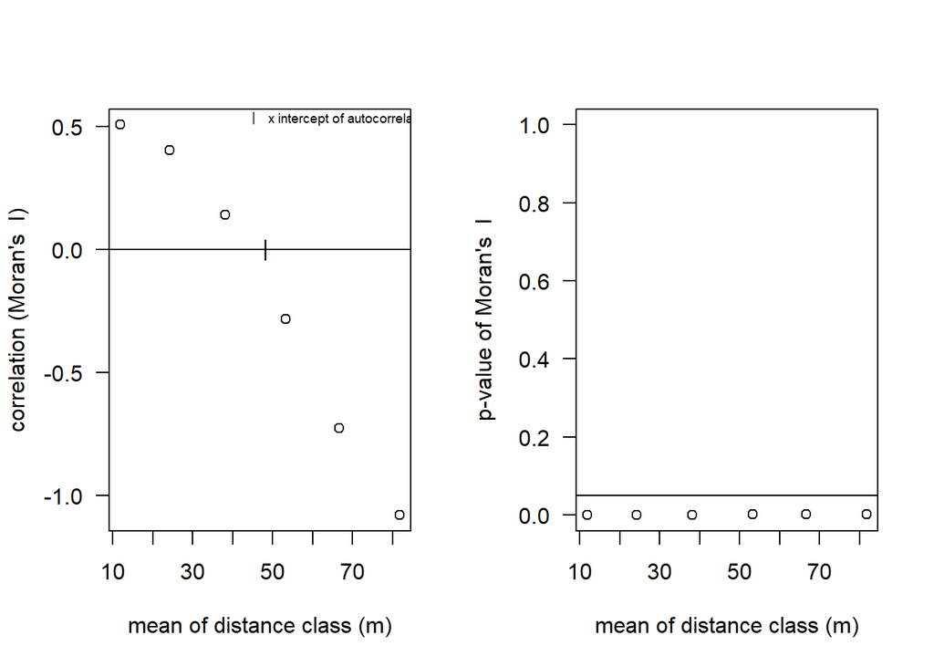

```r
x11(width=12, height=12) ####
par(mfrow=c(1,2))
plot(Cor.Mean_diameter$mean.of.class[1:6], Cor.Mean_diameter$correlation[1:6],
  xlab="mean of distance class (m)", ylab="correlation (Moran's  I)", las=1)
abline(0, 0)
points(Cor.Mean_diameter$x.intercept, 0, pch="|")
legend("topright", "x intercept of autocorrelation", pch="|", bty="n", cex=0.6)
 plot(Cor.Mean_diameter$mean.of.class[1:6], Cor.Mean_diameter$p[1:6], ylim=c(0,1),
  xlab="mean of distance class (m)", ylab="p-value of Moran's  I", las=1)
abline(0.05, 0)
```

```r
# dev.off() # turn off the graphics device
```

#### LME (Linear Mixed Effects)

##### With spatial autocorrelation’s correction included

A LME model is a mixed model is implemented to deal with pseudoreplicates by including random effects of, e.g., sites that meet the assumption of normal distribution of residuals. In addition to random effects, it can handle spatial autocorrelation. Therefore, if in a previous test (e.g. Moran’s I) you find significant spatial autocorrelation in a Linear Mixed Model (LMM; with random and fixed effects and normal distribution), you must use LME with a spatial correlation strucure in the model. If you have non-normal data with spatial auto-correlation please check the function glmmPQL of the package MASS to calculate a GLMM with a spatial correlation structure.

There are different variants of spatial correlation structures. One good example is Exponential correlation (function “corExp”). The correlation structure must be included in the syntax of the lme command as in the analyses below. If you don’t include a correlation function (e.g. corExp) in the LME model, it is just like a common LMM. However, like GLMM, this would not be enough to resolve the autocorrelation and provide reliable p-values. In order to test spatial autocorrelation by Moran’s I, you must first construct a LM with the same predictors that will be used in the LME (see LM model used in the section Linearity Tests and Moran’s I). To better understand this approach of handling spatial autocorrelation using the proper regression models, read Dormann et al. (2007).

Dormann, C.F., M. McPherson, J., B. Araújo, M., Bivand, R., Bolliger, J., Carl, G.et al. (2007). Methods to account for spatial autocorrelation in the analysis of species distributional data: A review. Ecography (Cop.)., 30, 609–628

Note 1: LMM can be calculated using either Maximum Likelihood (ML) or Restricted Maximum Likelihood (REML). If we are focusing on estimation and testing of fixed effects, we choose “ML”. In addition to correlation of the residuals, lme can also deal with heterogeneous variance of residuals (heteroscedasticity), e.g. when variances differ among groups, such as sites. For this purpose, we can use the “weights” argument.

```r
# install.packages("nlme")
# install.packages("car")

library(nlme) # LME models
library(car) # Anova type II gives the predictors the same chance of
             # being significant
```

```r
BIOVEG <- read.table("BIOVEG3.csv", header=T, sep=",", dec=".")
head(BIOVEG,4)
```

```
##           type Plot  Site                Species Richness Diameter
## 1 Semidecidual p001 AREA1 Alchornea_triplinervia        8    27.12
## 2 Semidecidual p002 AREA1     Amaioua_intermedia       10    39.15
## 3 Semidecidual p003 AREA1          Aniba_firmula       10    33.93
## 4 Semidecidual p004 AREA1          Annona_cacans       10    40.43
##   Mean_diameter Basal.area Abundance Precipitation_mean Temperature_mean
## 1         6.357      0.058         7               1250             24.4
## 2         6.524      0.120        12               1250             24.4
## 3         6.632      0.090        10               1250             24.4
## 4         6.626      0.128        19               1250             24.4
##   Mortality Recruitment local.x local.y  utm.x   utm.y local.utm.x
## 1      6.94       14.34       0       0 747923 7807727      747923
## 2      2.74        6.94     -10       0 747923 7807727      747913
## 3      1.71        2.35     -20       0 747923 7807727      747903
## 4      1.60        2.47     -30       0 747923 7807727      747893
##   local.utm.y
## 1     7807727
## 2     7807727
## 3     7807727
## 4     7807727
```

```r
Mean_diameter.lme<- lme(Mean_diameter ~ Mortality + Recruitment, data=BIOVEG,
              method="ML", random= ~1|Site, corr=corExp(form=~local.utm.x+
              local.utm.y|Site), weights=varIdent(form=~1|Site), na.action=na.omit)

summary(Mean_diameter.lme)
```

```
## Linear mixed-effects model fit by maximum likelihood
##  Data: BIOVEG
##       AIC      BIC   logLik
##   97.1106 121.1957 -40.5553
##
## Random effects:
##  Formula: ~1 | Site
##          (Intercept) Residual
## StdDev: 0.0001718405 2.831905
##
## Correlation Structure: Exponential spatial correlation
##  Formula: ~local.utm.x + local.utm.y | Site
##  Parameter estimate(s):
##    range
## 999.8204
## Variance function:
##  Structure: Different standard deviations per stratum
##  Formula: ~1 | Site
##  Parameter estimates:
##     AREA1     AREA2     AREA3
## 1.0000000 0.3103472 2.6947936
## Fixed effects: Mean_diameter ~ Mortality + Recruitment
##                 Value Std.Error  DF   t-value p-value
## (Intercept) 10.672167 0.8185581 145 13.037763  0.0000
## Mortality    0.001605 0.0032656 145  0.491505  0.6238
## Recruitment -0.003023 0.0091995 145 -0.328623  0.7429
##  Correlation:
##             (Intr) Mrtlty
## Mortality   -0.006
## Recruitment -0.032 -0.053
##
## Standardized Within-Group Residuals:
##         Min          Q1         Med          Q3         Max
## -1.51239300 -0.68377730 -0.01067181  0.29650175  1.46812947
##
## Number of Observations: 150
## Number of Groups: 3
```

```r
## Anova from car package

An<- Anova(Mean_diameter.lme, Type = II)
An
```

```
## Analysis of Deviance Table (Type II tests)
##
## Response: Mean_diameter
##              Chisq Df Pr(>Chisq)
## Mortality   0.2465  1     0.6195
## Recruitment 0.1102  1     0.7399
```

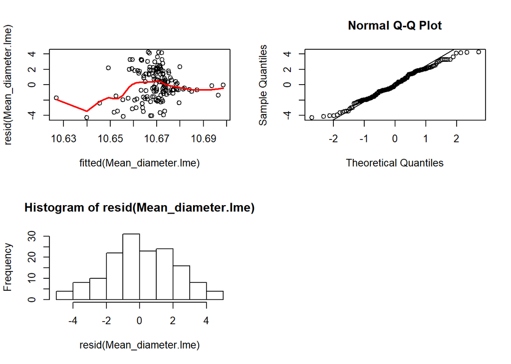

```r
## Residuals

x11(width=12, height=12) ####
par(mfrow=c(2,2))
plot(fitted(Mean_diameter.lme), resid(Mean_diameter.lme))
lines(smooth.spline(fitted(Mean_diameter.lme), resid(Mean_diameter.lme),
                                          spar=c(1)), col="red", lwd=2)
qqnorm(resid(Mean_diameter.lme))
qqline(resid(Mean_diameter.lme))
hist(resid(Mean_diameter.lme))
#dev.off() ## turn off the graphics device
```

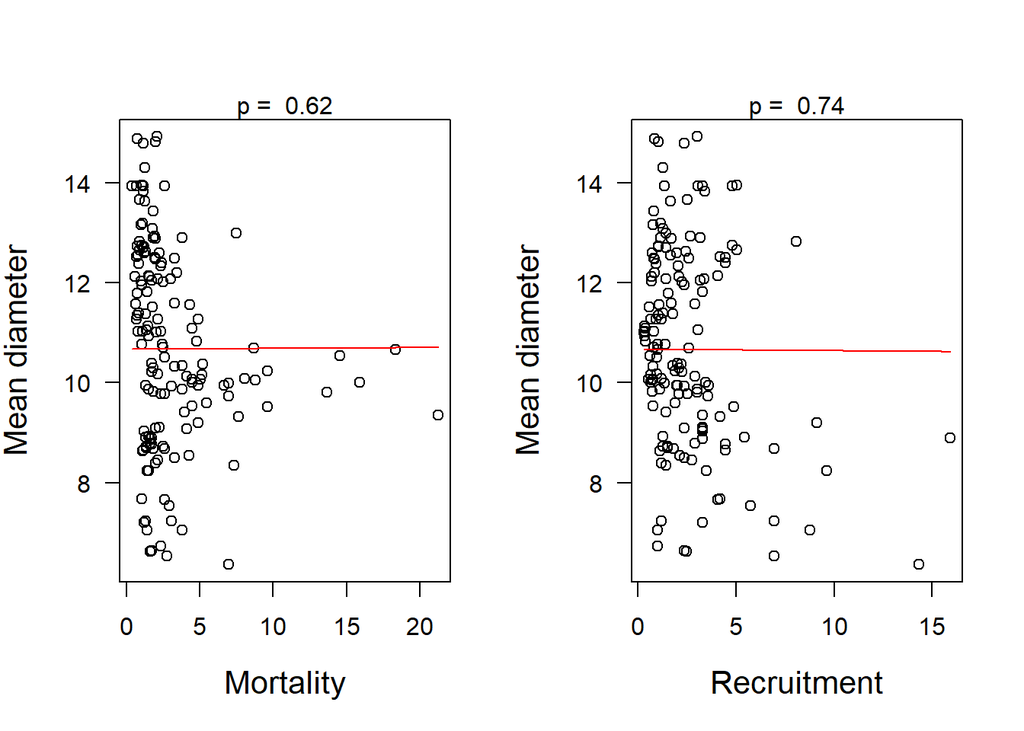

```r
## Scatterplot

b.0.Mean_diameter<- Mean_diameter.lme$coefficients$fixed[1]
b.1.Mean_diameter<- Mean_diameter.lme$coefficients$fixed[2]
b.2.Mean_diameter<- Mean_diameter.lme$coefficients$fixed[3]

x11(width=14, height=8)
par(mfrow=c(1,2))
plot(BIOVEG$Mean_diameter ~ BIOVEG$Mortality, las=1, ylab="Mean diameter", xlab="Mortality",
     cex.lab=1.3)
curve(b.0.Mean_diameter + b.1.Mean_diameter*x, add=TRUE, col="red")
mtext(ifelse(An[1,3]<0.001, "p < 0.001", paste("p = ", round(An[1,3],3))))
plot(BIOVEG$Mean_diameter ~ BIOVEG$Recruitment, las=1, ylab="Mean diameter", xlab="Recruitment",
     cex.lab=1.3)
curve(b.0.Mean_diameter + b.2.Mean_diameter*x, add=TRUE, col="red")
mtext(ifelse(An[2,3]<0.001, "p < 0.001", paste("p = ", round(An[2,3],3))))
```

```r
#dev.off() ## turn off the graphics device
```

#### GLS (Generalized Least Squares)

GLS is another variant of linear regression. It is mostly used to perform analysis when there is significant spatial (or temporal) correlation between the residuals (or if there is heteroscedasticity), but you do not have any random effect in the model. In the absence of random effects, you cannot use lme, but you can use gls. GLS models fit correlation structures of the variance-covariance matrix to model the (spatial) dependence of observations, just as LME models do. Thus, gls is an efficient tool to deal with spatial autocorrelation when you would otherwise use lm (read Dormann et al. 2007).

Dormann et al. Methods to account for spatial autocorrelation in the analysis of species distributional data: a review. Ecography 30: 609-628, 2007.

N.B. GLS assumes a normal distribution.

In cases such as in the example below, when you just want to know whether there is variation of a variable among treatments and study sites, for instance, but your data comes from pseudoreplicates (e.g. subplots in our example below), GLS is a good option. Notice that in this case, you use site as a fixed effect. Otherwise, if you want to include site as a random effect, you must use a mixed effect model (GLMM or LME). Before calculating a GLS model, you should use Moran’s I to check the significance of spatial autocorrelation. If significant autocorrelation is found, you must include a correlation structure in the model (e.g. correlation=corExp).

```r
## Pre-test: Spatial autocorrelation (Moran'I)

BIOVEG <- read.table("BIOVEG3.csv", header=T, sep=",", dec=".")
head(BIOVEG,4)
```

```
##           type Plot  Site                Species Richness Diameter
## 1 Semidecidual p001 AREA1 Alchornea_triplinervia        8    27.12
## 2 Semidecidual p002 AREA1     Amaioua_intermedia       10    39.15
## 3 Semidecidual p003 AREA1          Aniba_firmula       10    33.93
## 4 Semidecidual p004 AREA1          Annona_cacans       10    40.43
##   Mean_diameter Basal.area Abundance Precipitation_mean Temperature_mean
## 1         6.357      0.058         7               1250             24.4
## 2         6.524      0.120        12               1250             24.4
## 3         6.632      0.090        10               1250             24.4
## 4         6.626      0.128        19               1250             24.4
##   Mortality Recruitment local.x local.y  utm.x   utm.y local.utm.x
## 1      6.94       14.34       0       0 747923 7807727      747923
## 2      2.74        6.94     -10       0 747923 7807727      747913
## 3      1.71        2.35     -20       0 747923 7807727      747903
## 4      1.60        2.47     -30       0 747923 7807727      747893
##   local.utm.y
## 1     7807727
## 2     7807727
## 3     7807727
## 4     7807727
```

```r
## LM

Mean.Diameter.pre <- lm(Mean_diameter ~ Site, data=BIOVEG)
summary(Mean.Diameter.pre)
```

```
##
## Call:
## lm(formula = Mean_diameter ~ Site, data = BIOVEG)
##
## Residuals:
##      Min       1Q   Median       3Q      Max
## -2.14642 -0.57963 -0.01675  0.58659  1.94452
##
## Coefficients:
##             Estimate Std. Error t value Pr(>|t|)
## (Intercept)   8.5034     0.1168   72.81   <2e-16 ***
## SiteAREA2     2.1837     0.1652   13.22   <2e-16 ***
## SiteAREA3     4.4821     0.1652   27.14   <2e-16 ***
## ---
## Signif. codes:  0 '***' 0.001 '**' 0.01 '*' 0.05 '.' 0.1 ' ' 1
##
## Residual standard error: 0.8258 on 147 degrees of freedom
## Multiple R-squared:  0.8336, Adjusted R-squared:  0.8314
## F-statistic: 368.3 on 2 and 147 DF,  p-value: < 2.2e-16
```

```r
shapiro.test(BIOVEG$Mean_diameter)
```

```
##
##  Shapiro-Wilk normality test
##
## data:  BIOVEG$Mean_diameter
## W = 0.98496, p-value = 0.1022
```

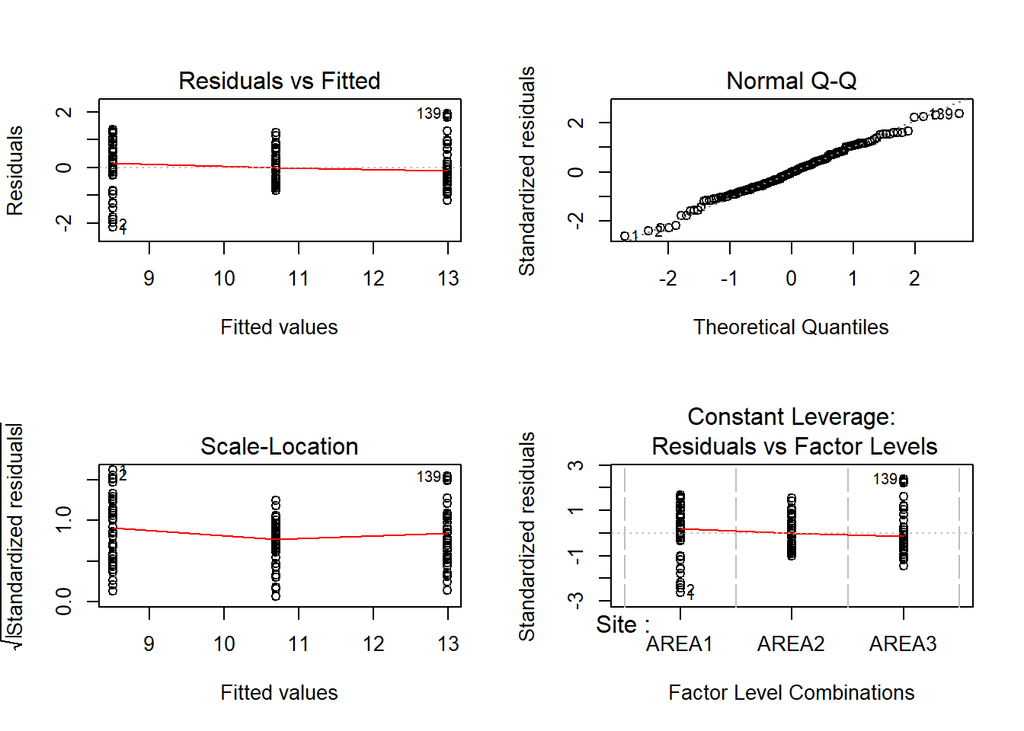

```r
# Residuals

x11(width=12, height=12)
par(mfrow=c(2,2))
plot(Mean.Diameter.pre)
```

```r
dev.off() ## turn off the graphics device
```

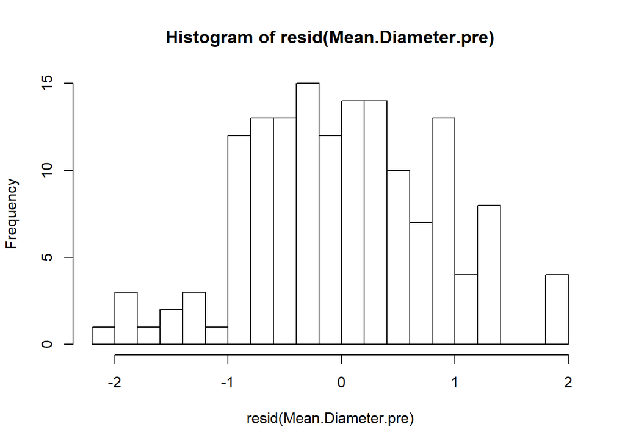

```r
x11(width=12, height=12)
hist(resid(Mean.Diameter.pre),breaks=20)
```

```r
# dev.off() ## turn off the graphics device
```

```r
## Moran's I

library(lctools) # Moran's I

Moran.M.diameter <- moransI(Coords=cbind(BIOVEG$local.utm.x, BIOVEG$local.utm.y),
                   Bandwidth=4, resid(Mean.Diameter.pre), WType="Binary")

Moran.M.diameter$Morans.I
```

```
##         1
## 0.6691855
```

```r
Moran.M.diameter$p.value.resampling # significance of the Moran's I
```

```
##            1
## 6.116947e-41
```

```r
Moran.M.diameter$p.value.randomization
```

```
##            1
## 6.556257e-41
```

#### GLS model

Since we found significant spatial autocorrelation in the pre-test with Moran’s I, a correlation (corExp) structure must be added in the syntax of the model

```r
library(nlme)
library(car)

Mean.diam.site<- gls(Mean_diameter ~ Site, correlation=corExp(form=~1|Site),
                     data=BIOVEG)

summary(Mean.diam.site)
```

```
## Generalized least squares fit by REML
##   Model: Mean_diameter ~ Site
##   Data: BIOVEG
##        AIC      BIC    logLik
##   204.1488 219.1009 -97.07439
##
## Correlation Structure: Exponential spatial correlation
##  Formula: ~1 | Site
##  Parameter estimate(s):
##    range
## 10.55233
##
## Coefficients:
##                Value Std.Error   t-value p-value
## (Intercept) 8.391105 0.6110569 13.732118  0.0000
## SiteAREA2   2.361087 0.8641649  2.732218  0.0071
## SiteAREA3   4.646891 0.8641649  5.377319  0.0000
##
##  Correlation:
##           (Intr) SAREA2
## SiteAREA2 -0.707
## SiteAREA3 -0.707  0.500
##
## Standardized residuals:
##         Min          Q1         Med          Q3         Max
## -1.82692630 -0.57058862 -0.03421433  0.53862327  1.69929827
##
## Residual standard error: 1.113403
## Degrees of freedom: 150 total; 147 residual
```

```r
An<- Anova(Mean.diam.site)
An
```

```
## Analysis of Deviance Table (Type II tests)
##
## Response: Mean_diameter
##      Df  Chisq Pr(>Chisq)
## Site  2 28.918  5.254e-07 ***
## ---
## Signif. codes:  0 '***' 0.001 '**' 0.01 '*' 0.05 '.' 0.1 ' ' 1
```

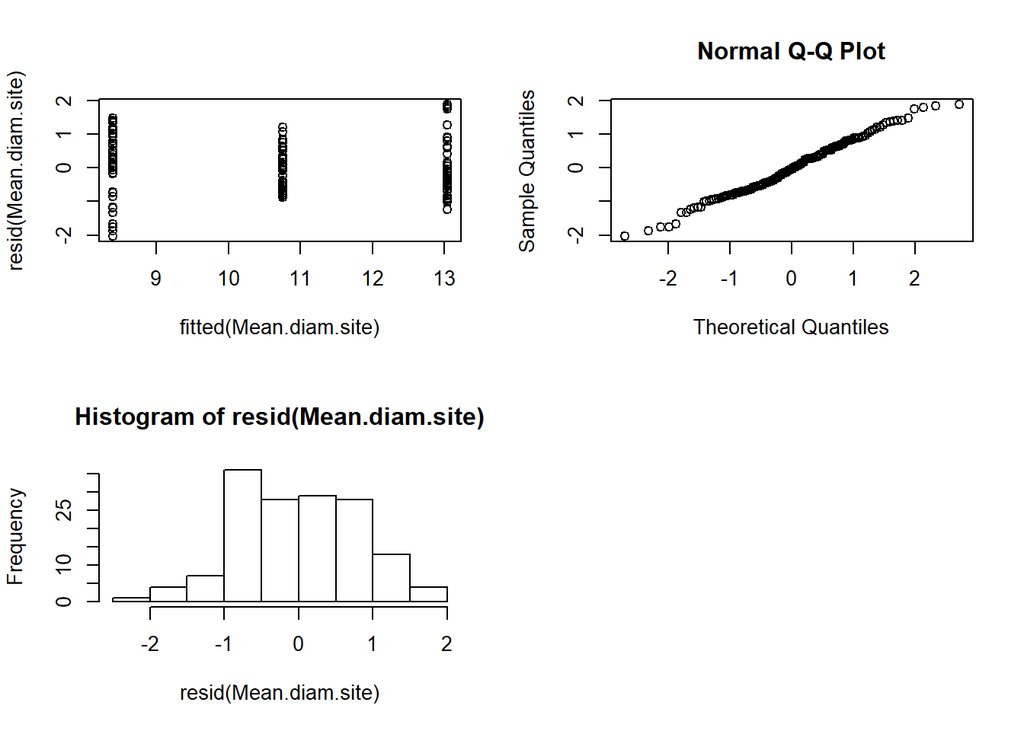

```r
# Residuals

x11(width=12, height=12)
par(mfrow=c(2,2))
plot(fitted(Mean.diam.site), resid(Mean.diam.site))
qqnorm(resid(Mean.diam.site))
hist(resid(Mean.diam.site))
# dev.off()
```

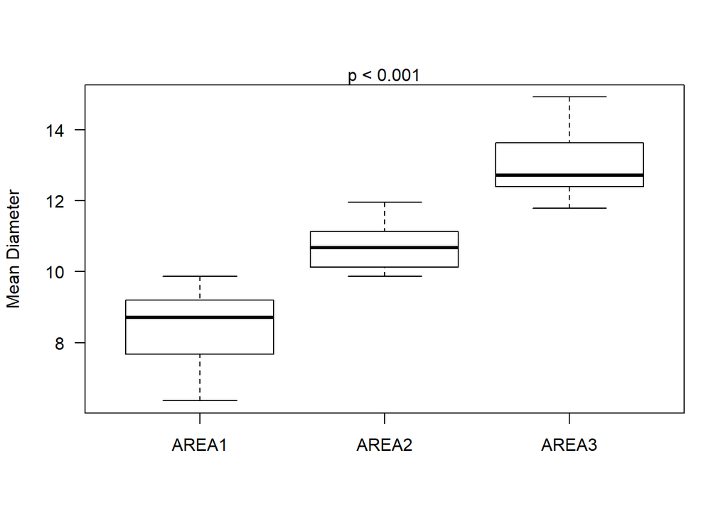

```r
# Boxplot

x11(width=12, height=12)
par(mfrow=c(1,1))
boxplot(BIOVEG$Mean_diameter ~ BIOVEG$Site, las=1, ylab="Mean Diameter")
mtext(ifelse(An[1,3]<0.001, "p < 0.001", paste("p = ", round(An[1,3],3))))
```

```r
# dev.off()
```

#### QUADRATIC MODEL

A quadratic regression is an extension of simple linear regression aiming to find the best fit equation a set of data (dependent and predictor variables) shaped like a parabola (e.g. U-shape curve). A quadratic fit is useful When the coefficients and, consequently, the curve appear to fit the data better than the linear model does.

Create linear model of species richness vs. Hogweed cover

```r
Hogweed <- read.table("Hogweed.csv", header=T, sep=",", dec=".")
head(Hogweed,4)
```

```
##   Plot Study.area  Habitat.type Year Veg.height Veg.cover Species.richness
## 1   s1        VOL ruderal.grass 2002        0.5        70               18
## 2   s2        VOL ruderal.grass 2002        0.7        65               19
## 3   s3        VOL ruderal.grass 2002        0.4        30               16
## 4   s4        VOL ruderal.grass 2002        0.9        90               23
##   Hogweed.height Hogweed.cover Land.use Disturbance Altitude Inclination
## 1            0.9            80     NONE   TREESHRUB  295.653           2
## 2            1.4            65     NONE   TREESHRUB  295.653           2
## 3            1.7            90     NONE   TREESHRUB  295.653           2
## 4            1.0            20     NONE        NONE  292.112           2
##   Exposition N_perc P_mg_100g K_mg_100g
## 1          W   0.19      3.99     22.27
## 2          W   0.19      3.56     12.49
## 3          W   0.19      8.44     39.95
## 4          W   0.12      2.53     12.34
```

```r
M.lin <- glm(Species.richness ~ Hogweed.cover + Habitat.type, data=Hogweed,
             family="quasipoisson")
summary(M.lin)
```

```
##
## Call:
## glm(formula = Species.richness ~ Hogweed.cover + Habitat.type,
##     family = "quasipoisson", data = Hogweed)
##
## Deviance Residuals:
##     Min       1Q   Median       3Q      Max
## -4.3435  -1.2231  -0.2592   1.2230   4.0514
##
## Coefficients:
##                            Estimate Std. Error t value Pr(>|t|)
## (Intercept)                3.248210   0.059719  54.392  < 2e-16 ***
## Hogweed.cover             -0.003072   0.001094  -2.807  0.00551 **
## Habitat.typeruderal.grass -0.022699   0.080921  -0.281  0.77938
## Habitat.typetall.herbs    -0.428306   0.083712  -5.116 7.43e-07 ***
## Habitat.typewasteland     -0.101591   0.106856  -0.951  0.34292
## Habitat.typewoodland      -0.354923   0.111048  -3.196  0.00163 **
## ---
## Signif. codes:  0 '***' 0.001 '**' 0.01 '*' 0.05 '.' 0.1 ' ' 1
##
## (Dispersion parameter for quasipoisson family taken to be 2.884375)
##
##     Null deviance: 775.16  on 200  degrees of freedom
## Residual deviance: 571.60  on 195  degrees of freedom
## AIC: NA
##
## Number of Fisher Scoring iterations: 4
```

```r
anova(M.lin, test = "F")
```

```
## Analysis of Deviance Table
##
## Model: quasipoisson, link: log
##
## Response: Species.richness
##
## Terms added sequentially (first to last)
##
##
##               Df Deviance Resid. Df Resid. Dev      F    Pr(>F)
## NULL                            200     775.16
## Hogweed.cover  1   70.215       199     704.94 24.343 1.723e-06 ***
## Habitat.type   4  133.345       195     571.60 11.557 1.929e-08 ***
## ---
## Signif. codes:  0 '***' 0.001 '**' 0.01 '*' 0.05 '.' 0.1 ' ' 1
```

Hogweed cover has a significant negative linear effect on species richness

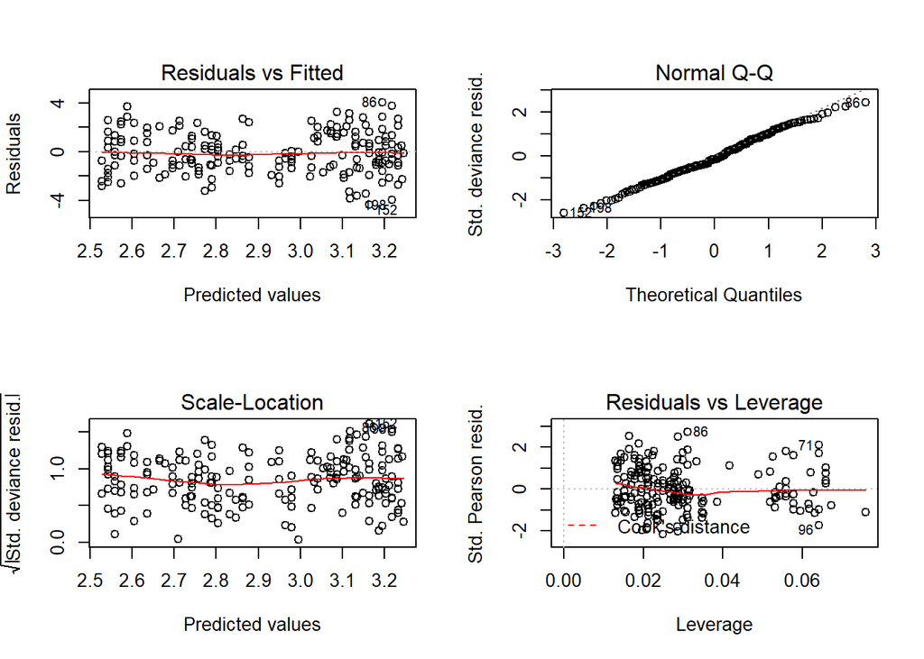

```r
# Model diangostics

par(mfrow = c(2, 2))
plot(M.lin)
```

The diagnostic graphs look ok.

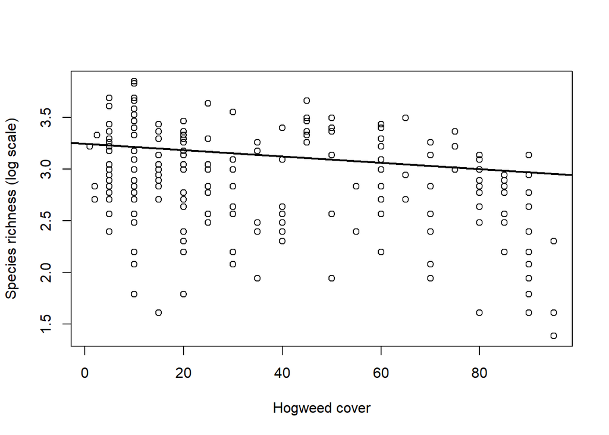

```r
# Plot the data and the regression line

par(mfrow = c(1, 1))
plot(log(Species.richness) ~ Hogweed.cover, data = Hogweed,
     xlab = "Hogweed cover", ylab = "Species richness (log scale)")
abline(glm(Species.richness ~ Hogweed.cover + Habitat.type, data=Hogweed,
           family="quasipoisson"), lwd = 2)
```

The plot suggests that a quadartic model mignt fit the data even better

```r
# Create variable of centered and squared Hogweed cover

Mean.cover <- mean(Hogweed$Hogweed.cover)
Hogweed.cover.sq <- (Hogweed$Hogweed.cover - Mean.cover)^2
```

Calculate the model with original and, additionally, squared Hogweed cover

```r
M.quad <- glm(Species.richness ~ Hogweed.cover + Hogweed.cover.sq + Habitat.type,
              data=Hogweed, family="quasipoisson")
summary(M.quad)
```

```
##
## Call:
## glm(formula = Species.richness ~ Hogweed.cover + Hogweed.cover.sq +
##     Habitat.type, family = "quasipoisson", data = Hogweed)
##
## Deviance Residuals:
##     Min       1Q   Median       3Q      Max
## -4.3890  -1.3328  -0.2187   1.0562   4.2712
##
## Coefficients:
##                             Estimate Std. Error t value Pr(>|t|)
## (Intercept)                3.286e+00  6.258e-02  52.502  < 2e-16 ***
## Hogweed.cover             -1.718e-03  1.303e-03  -1.319 0.188639
## Hogweed.cover.sq          -8.413e-05  4.408e-05  -1.908 0.057825 .
## Habitat.typeruderal.grass -5.146e-02  8.144e-02  -0.632 0.528221
## Habitat.typetall.herbs    -4.418e-01  8.299e-02  -5.324 2.79e-07 ***
## Habitat.typewasteland     -1.010e-01  1.060e-01  -0.952 0.342054
## Habitat.typewoodland      -3.748e-01  1.107e-01  -3.387 0.000855 ***
## ---
## Signif. codes:  0 '***' 0.001 '**' 0.01 '*' 0.05 '.' 0.1 ' ' 1
##
## (Dispersion parameter for quasipoisson family taken to be 2.838361)
##
##     Null deviance: 775.16  on 200  degrees of freedom
## Residual deviance: 561.23  on 194  degrees of freedom
## AIC: NA
##
## Number of Fisher Scoring iterations: 4
```

```r
anova(M.quad, test="F")
```

```
## Analysis of Deviance Table
##
## Model: quasipoisson, link: log
##
## Response: Species.richness
##
## Terms added sequentially (first to last)
##
##
##                  Df Deviance Resid. Df Resid. Dev       F    Pr(>F)
## NULL                               200     775.16
## Hogweed.cover     1   70.215       199     704.94 24.7377 1.442e-06 ***
## Hogweed.cover.sq  1   10.471       198     694.47  3.6891   0.05623 .
## Habitat.type      4  133.242       194     561.23 11.7358 1.479e-08 ***
## ---
## Signif. codes:  0 '***' 0.001 '**' 0.01 '*' 0.05 '.' 0.1 ' ' 1
```

Compare linear and quadratic model

```r
anova(M.lin, M.quad, test = "F")
```

```
## Analysis of Deviance Table
##
## Model 1: Species.richness ~ Hogweed.cover + Habitat.type
## Model 2: Species.richness ~ Hogweed.cover + Hogweed.cover.sq + Habitat.type
##   Resid. Df Resid. Dev Df Deviance      F  Pr(>F)
## 1       195     571.60
## 2       194     561.23  1   10.368 3.6527 0.05745 .
## ---
## Signif. codes:  0 '***' 0.001 '**' 0.01 '*' 0.05 '.' 0.1 ' ' 1
```

Squared hogweed cover is (marginally) not significant.

Anyway, let’s create a scatter plot with regression curve.

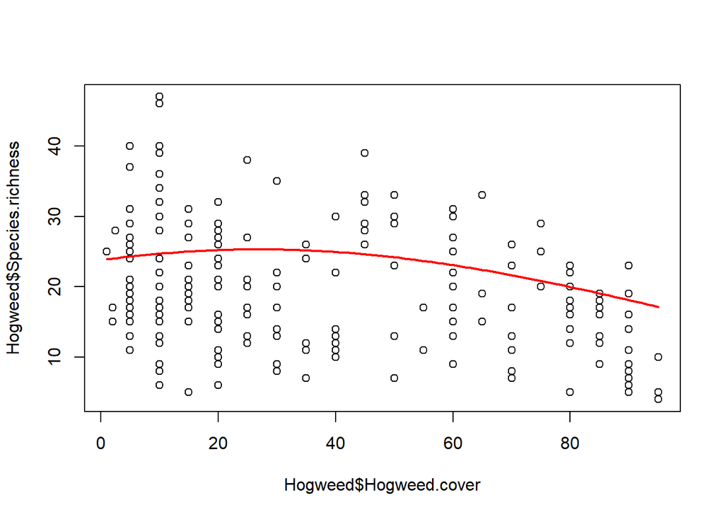

```r
plot(Hogweed$Species.richness ~ Hogweed$Hogweed.cover)

b0 <- coef(M.quad)[1] # Intercept
b1 <- coef(M.quad)[2] # Hogweed cover linear
b2 <- coef(M.quad)[3] # Hogwee cover squared
# In the curve syntax, we need to center and square "x" before multiplying it with
# the coefficient of Hogweed.cover.sq.
curve(exp(b0 + b1*x + b2*(x-Mean.cover)^2), add=T, col="red", lwd=2)
```